# deer_burn

R Pienaar

2025-02-11

Libraries

```r
# Load in libraries
library(camtrapR)
library(dplyr)
library(ggplot2)
library(devtools)
library(unmarked)
library(scales)
library(lubridate)
# Install autoOcc incase you have not yet
# devtools::install_github(
#   "mfidino/autoOcc",
#   build_vignettes = TRUE
# )
library(autoOcc)
library(extrafont)
library(ggpubr)
```

```r
#Load deer tables
ct <- read.csv("C:/Users/ryanp/Documents/Academia/Dissertation/Chapter4_Camera traps/Camelot Exports/Record Tables/ct_summary.csv")
head(ct)
```

```
##     Station Camera    gps_y     gps_x Setup_date Retrieval_date Session
## 1 CLE_A_000     57 39.88096 -111.2653  9/21/2019      7/13/2023       1
## 2 CLE_A_100      4 39.88054 -111.2655  9/22/2019      7/13/2023       1
## 3 CLE_J_000     72 39.92925 -111.2230  9/22/2019      7/13/2023       1
## 4 CLE_J_100      5 39.92877 -111.2245  9/21/2019      7/13/2023       1
## 5 DA2_J_000      6 39.96193 -111.3438 10/25/2019      7/13/2023       1
## 6 DA2_J_100      7 39.96249 -111.3453 10/25/2019      7/13/2023       1
##   ProblemX_from ProblemX_to
## 1            NA          NA
## 2            NA          NA
## 3            NA          NA
## 4            NA          NA
## 5            NA          NA
## 6            NA          NA
```

```r
data <- read.csv("C:/Users/ryanp/Documents/Academia/Dissertation/Chapter4_Camera traps/Camelot Exports/Record Tables/Record_table_mainpulated.csv")
head(data)
```

```
##     Station Camera CameraName             Species TrapAndCamera
## 1 CLE_J_000     72  CLE_J_000 Odocoileus hemionus  CLE_J_000_72
## 2 CLE_A_100      4  CLE_A_100          Ovis aries   CLE_A_100_4
## 3 CLE_A_100      4  CLE_A_100          Ovis aries   CLE_A_100_4
## 4 CLE_A_100      4  CLE_A_100          Ovis aries   CLE_A_100_4
## 5 PAS_A_100     26  PAS_A_100          Bos taurus  PAS_A_100_26
## 6 PAS_A_100     26  PAS_A_100 Odocoileus hemionus  PAS_A_100_26
##   DateTimeOriginal      Date     Time delta.time.secs delta.time.mins
## 1   9/23/2019 8:07 9/23/2019  8:07:19               0               0
## 2   9/25/2019 9:00 9/25/2019  9:00:13               0               0
## 3   9/25/2019 9:23 9/25/2019  9:23:21            1388              23
## 4  9/25/2019 10:25 9/25/2019 10:25:09            3708              61
## 5  9/28/2019 18:38 9/28/2019 18:38:29               0               0
## 6  9/29/2019 10:29 9/29/2019 10:29:17               0               0
##   delta.time.hours delta.time.days
```

[output cut: 20 more lines]

```r
# Create a detection history for each Year
camop <- cameraOperation(CTtable      = ct,
                                    stationCol   = "Station",
                                    sessionCol = "Session",
                                    setupCol     = "Setup_date",
                                    retrievalCol = "Retrieval_date",
                                    hasProblems  = FALSE,
                                    dateFormat   = "mdy")
# without trapping effort
DetHist1 <- detectionHistory(recordTable         = data,
                            camOp                = camop,
                           species = "Odocoileus hemionus",
                            stationCol = "Station",
                            speciesCol = "Species",
                            recordDateTimeCol = "Date",
                            recordDateTimeFormat = "mdy",
                            occasionLength = 14,
                            scaleEffort = FALSE,
                            timeZone = "MST",
                            day1 = "survey",
                            unmarkedMultFrameInput = TRUE)
DetHist1$detection_history
```

```
##           o1 o2 o3 o4 o5 o6 o7 o8 o9 o10 o11 o12 o13 o14 o15 o16 o17 o18 o19
## CLE_A_000  0  1  1  0  0  1  0  0  0   0   0   0   0   0   0   0   1   1   1
## CLE_A_100  0  0  0  1  0  0  0  0  0   0   0   0   0   0   0   0   0   0   1
## CLE_J_000  1  0  0  0  0  1  0  0  1   0   0   0   1   0   1   0   1   1   1
## CLE_J_100  1  1  1  1  0  0  0  1  1   0   0   0   0   0   0   0   0   0   0
## DA2_J_000 NA NA  0  0  0  0  0  0  0   0   0   0   0   0   0   0   0   0   0
## DA2_J_100 NA NA  0  1  1  0  0  0  0   0   0   0   0   0   0   0   0   0   0
## DAI_A_000  1  0  0  0  0  0  0  0  0   0   0   0   0   0   0   0   1   1   1
## DAI_A_100  0  1  1  0  0  1  0  0  0   0   0   0   0   0   0   0   1   1   1
## DAI_J_000 NA NA  0  0  1  0  0  1  0   0   0   1   0   0   0   0   1   0   0
## DAI_J_100 NA NA  0  0  0  0  0  0  0   0   0   0   0   0   0   0   0   0   0
## DAI_M_000 NA NA  0  0  0  0  0  0  0   0   0   0   0   0   0   0   0   0   0
## DAI_M_100 NA NA  0  0  0  0  0  0  0   0   0   0   0   0   0   0   0   0   0
## DAN_J_000 NA NA  0  0  0  0  0  0  0   0   0   0   0   0   0   0   0   0   0
## DAN_J_100 NA NA  0  0  0  0  0  0  0   0   0   0   0   0   0   0   0   0   0
## DEV_A_000  0  0  0  0  0  0  0  0  0   0   0   0   0   0   0   0   0   0   0
## DEV_A_100  1  0  1  0  0  0  0  0  0   0   0   0   0   0   0   0   0   0   0
## DFL_J_000 NA NA  1  1  1  1  1  1  1   1   0   0   0   0   0   0   0   0   0
## DFL_J_100 NA NA  0  1  0  0  1  0  1   1   1   1   1   1   0   0   0   0   0
## LDF_M_000  0  0  0  0  0  0  0  0  0   0   0   0   0   0   0   0   0   0   0
## LDF_M_100  0  0  0  0  1  1  1  0  1   0   0   0   1   1   1   1   1   1   1
## NEB_J_000 NA NA  0  1  1  0  0  0  0   1   0   0   0   0   0   0   0   0   0
## NEB_J_100 NA NA  1  1  0  1  0  0  1   1   1   1   1   1   1   0   0   0   0
## PAS_A_000  0  0  1  1  0  0  0  0  0   0   0   0   0   0   0   0   1   1   0
## PAS_A_100  1  0  0  0  0  0  0  0  0   0   0   0   0   0   0   0   0   1   1
## PAY_A_000  0  0  0  0  0  0  0  0  0   0   0   0   0   0   0   0   0   1   1
## PAY_A_100  0  0  0  0  0  0  0  0  0   0   0   0   0   0   0   0   0   0   0
## WAN_M_000  0  0  0  0  0  0  0  1  0   0   0   0   0   0   0   1   0   1   0
## WAN_M_100  1  1  1  1  0  1  0  1  1   0   0   0   0   0   1   1   1   1   1
## WIN_A_000 NA  0  0  0  0  0  0  0  0   0   0   0   0   0   0   0   0   0   0
## WIN_A_100 NA  0  0  0  0  0  0  0  0   0   0   0   0   0   0   0   0   0   0
## WIN_M_000  0  0  0  0  0  0  0  0  0   0   0   0   0   0   0   0   0   0   0
## WIN_M_100 NA  1  1  0  0  0  0  0  0   0   0   0   0   0   0   0   0   0   0
##           o20 o21 o22 o23 o24 o25 o26 o27 o28 o29 o30 o31 o32 o33 o34 o35 o36
## CLE_A_000   1   0   0   0   0   0   0   0   0   0   0   0   0   0   0   0   0
## CLE_A_100   1   0   0   0   0   0   0   0   0   0   0   0   0   0   0   0   0
## CLE_J_000   0   1   1   0   0   0   1   1   0   0   0   0   0   0   0   0   0
## CLE_J_100   0   0   0   0   0   0   0   0   0   0   0   0   0   0   0   0   0
## DA2_J_000   0   0   0   0   0   0   0   0   0   0   0   0   0   0   0   0   0
## DA2_J_100   0   0   0   0   0   0   0   0   0   0   0   0   0   0   0   0   0
```

[output cut: 143 more lines]

```
## DFL_J_100   1   0   0   0   1   1   1   1   1   1   1   1   NA
## LDF_M_000   0   0   0   0   0   0   0   0   0   0  NA  NA   NA
## LDF_M_100   0   0   0   0   0   0   0   1   1   1   0   1   NA
## NEB_J_000   1   1   1   0   1   1   1   1   1   1   1   1   NA
## NEB_J_100   0   0   0   0   1   1   1   1   1   1   1   0   NA
## PAS_A_000  NA  NA  NA  NA  NA  NA  NA  NA  NA  NA  NA  NA   NA
## PAS_A_100   0   0   0   0   0   0   0   0   1   1   1   1    1
## PAY_A_000  NA  NA  NA  NA  NA  NA  NA  NA  NA  NA  NA  NA   NA
## PAY_A_100   0   0   0   0   0   0   0   0   0   0   0   0    0
## WAN_M_000   0   0   0   0   0   0   0   0   0   0   0   0    0
## WAN_M_100   0   0   0   0   0   0   0   1   1   0   1   1   NA
## WIN_A_000   0   0   0   0   0   0   0   0   1   1   1   1    1
## WIN_A_100  NA  NA  NA  NA  NA  NA  NA  NA  NA  NA  NA  NA   NA
## WIN_M_000  NA  NA  NA  NA  NA  NA  NA  NA  NA  NA  NA  NA   NA
## WIN_M_100  NA  NA  NA  NA  NA  NA  NA  NA  NA  NA  NA  NA   NA
```

```r
deerdh <- DetHist1$detection_history
head(deerdh)
```

```
##           o1 o2 o3 o4 o5 o6 o7 o8 o9 o10 o11 o12 o13 o14 o15 o16 o17 o18 o19
## CLE_A_000  0  1  1  0  0  1  0  0  0   0   0   0   0   0   0   0   1   1   1
## CLE_A_100  0  0  0  1  0  0  0  0  0   0   0   0   0   0   0   0   0   0   1
## CLE_J_000  1  0  0  0  0  1  0  0  1   0   0   0   1   0   1   0   1   1   1
## CLE_J_100  1  1  1  1  0  0  0  1  1   0   0   0   0   0   0   0   0   0   0
## DA2_J_000 NA NA  0  0  0  0  0  0  0   0   0   0   0   0   0   0   0   0   0
## DA2_J_100 NA NA  0  1  1  0  0  0  0   0   0   0   0   0   0   0   0   0   0
##           o20 o21 o22 o23 o24 o25 o26 o27 o28 o29 o30 o31 o32 o33 o34 o35 o36
## CLE_A_000   1   0   0   0   0   0   0   0   0   0   0   0   0   0   0   0   0
## CLE_A_100   1   0   0   0   0   0   0   0   0   0   0   0   0   0   0   0   0
## CLE_J_000   0   1   1   0   0   0   1   1   0   0   0   0   0   0   0   0   0
## CLE_J_100   0   0   0   0   0   0   0   0   0   0   0   0   0   0   0   0   0
## DA2_J_000   0   0   0   0   0   0   0   0   0   0   0   0   0   0   0   0   0
## DA2_J_100   0   0   0   0   0   0   0   0   0   0   0   0   0   0   0   0   0
##           o37 o38 o39 o40 o41 o42 o43 o44 o45 o46 o47 o48 o49 o50 o51 o52 o53
## CLE_A_000   0   0   0   0   0   0   0   0   0   0   0   0   0   0   0   0   0
## CLE_A_100   0   0   0   0   0   0   0   0   0   0   0   0   0   1   0   1   0
## CLE_J_000   0   0   0   0   0   0   0   0   0   0   0   1   1   1   1   1   1
## CLE_J_100   0   0   0   0   0   0   0   0   0   0   0   1   0   1   1   1   1
## DA2_J_000   1   0   0   0   0   0   0   0   0   0   0   1   0   0   1   1   0
## DA2_J_100   0   0   0   0   0   0   1   1   0   0   0   0   0   1   0   1   0
##           o54 o55 o56 o57 o58 o59 o60 o61 o62 o63 o64 o65 o66 o67 o68 o69 o70
## CLE_A_000   1   0   0   0   0   0   0   0   0   0   0   0   0   0   0   0   0
## CLE_A_100   1   1   1   1   1   0   0   0   0   0   0   0   0   0   0   0   1
## CLE_J_000   1   0   0   0   1   0   0   0   0   0   0   0   1   1   1   1   1
## CLE_J_100   1   1   0   1   1   1   1   0   0   0   0   0   0   1   1   1   1
## DA2_J_000   1   1   1   1   1   0   0   0   0   0   0   0   1   1   1   1   1
## DA2_J_100   0   1   0   0   1   0   0   0   0   0   0   0   0   0   1   1   0
##           o71 o72 o73 o74 o75 o76 o77 o78 o79 o80 o81 o82 o83 o84 o85 o86 o87
## CLE_A_000   0   0   1   1   0   1   1   1   1   1   0   0   0   0   0   0   0
## CLE_A_100   1   1   1   1   1   1   1   1   1   1   1   1   0   1   0   0   0
## CLE_J_000   1   1   1   1   1   1   1   1   1   1   1   0   0   1   1   1   0
## CLE_J_100   1   1   1   0   0   0   0   0   1   0   1   1   1   1   1   1   0
## DA2_J_000   1   1   1   1   0   0   0   1   1   1   1   0   0   1   0   1   0
## DA2_J_100   1   1   1   1   1   0   1   1   1   0   0   1   1   1   1   0   1
##           o88 o89 o90 o91 o92 o93 o94 o95 o96 o97 o98 o99 o100
## CLE_A_000   0   0   0   0   0   0   0   0   0   0   1   0    0
## CLE_A_100   0   0   0   0   0   0   0   0   0   1   1   0    1
## CLE_J_000   0   0   0   0   0   0   1   1   1   1   1   1    1
## CLE_J_100   0   0   0   0   0   0   1   1   1   1   1   1    1
## DA2_J_000   0   0   0   0   0   0   1   1   1   1   1   1    1
## DA2_J_100   0   0   0   0   0   0   1   1   1   1   1   1    0
```

```r
s1 <- deerdh[,1:25]
#s1$Year <- 1
s2 <- deerdh[,26:50]
#s2$Year <- 2
s3 <- deerdh[,51:75]
#s3$Year <- 3
s4 <- deerdh[,76:100]
#s4$Year <- 4

dh <- rbind(s1,s2,s3,s4)

sequence <- rep(1:4, each = 32)
dh <- as.data.frame(dh)
dh$Year<- sequence
dh$site <- substr(row.names(dh),1,9)

#Create covariates for each site
deer_covariates <- as.data.frame(rownames(DetHist1$detection_history))
deer_covariates$Forest <- substr(deer_covariates$`rownames(DetHist1$detection_history)`,5,5)
deer_covariates$Fire <- substr(deer_covariates$`rownames(DetHist1$detection_history)`,7,7)
dh$Year
```

```
##   [1] 1 1 1 1 1 1 1 1 1 1 1 1 1 1 1 1 1 1 1 1 1 1 1 1 1 1 1 1 1 1 1 1 2 2 2 2 2
##  [38] 2 2 2 2 2 2 2 2 2 2 2 2 2 2 2 2 2 2 2 2 2 2 2 2 2 2 2 3 3 3 3 3 3 3 3 3 3
##  [75] 3 3 3 3 3 3 3 3 3 3 3 3 3 3 3 3 3 3 3 3 3 3 4 4 4 4 4 4 4 4 4 4 4 4 4 4 4
## [112] 4 4 4 4 4 4 4 4 4 4 4 4 4 4 4 4 4
```

```r
#### Create a list of seasons ####
# Create the original list of dates
start_date <- as.Date("2019-09-23")
original_dates <- seq.Date(start_date, by = "14 days", length.out = 100)
original_dates
```

```
##   [1] "2019-09-23" "2019-10-07" "2019-10-21" "2019-11-04" "2019-11-18"
##   [6] "2019-12-02" "2019-12-16" "2019-12-30" "2020-01-13" "2020-01-27"
##  [11] "2020-02-10" "2020-02-24" "2020-03-09" "2020-03-23" "2020-04-06"
##  [16] "2020-04-20" "2020-05-04" "2020-05-18" "2020-06-01" "2020-06-15"
##  [21] "2020-06-29" "2020-07-13" "2020-07-27" "2020-08-10" "2020-08-24"
##  [26] "2020-09-07" "2020-09-21" "2020-10-05" "2020-10-19" "2020-11-02"
##  [31] "2020-11-16" "2020-11-30" "2020-12-14" "2020-12-28" "2021-01-11"
##  [36] "2021-01-25" "2021-02-08" "2021-02-22" "2021-03-08" "2021-03-22"
##  [41] "2021-04-05" "2021-04-19" "2021-05-03" "2021-05-17" "2021-05-31"
##  [46] "2021-06-14" "2021-06-28" "2021-07-12" "2021-07-26" "2021-08-09"
##  [51] "2021-08-23" "2021-09-06" "2021-09-20" "2021-10-04" "2021-10-18"
##  [56] "2021-11-01" "2021-11-15" "2021-11-29" "2021-12-13" "2021-12-27"
##  [61] "2022-01-10" "2022-01-24" "2022-02-07" "2022-02-21" "2022-03-07"
##  [66] "2022-03-21" "2022-04-04" "2022-04-18" "2022-05-02" "2022-05-16"
##  [71] "2022-05-30" "2022-06-13" "2022-06-27" "2022-07-11" "2022-07-25"
##  [76] "2022-08-08" "2022-08-22" "2022-09-05" "2022-09-19" "2022-10-03"
##  [81] "2022-10-17" "2022-10-31" "2022-11-14" "2022-11-28" "2022-12-12"
##  [86] "2022-12-26" "2023-01-09" "2023-01-23" "2023-02-06" "2023-02-20"
##  [91] "2023-03-06" "2023-03-20" "2023-04-03" "2023-04-17" "2023-05-01"
##  [96] "2023-05-15" "2023-05-29" "2023-06-12" "2023-06-26" "2023-07-10"
```

```r
# Function to determine the season
get_season <- function(date) {
  month <- month(date)
  if (month %in% c(11, 12, 1, 2)) {
    return("Winter")
  } else if (month %in% c(3, 4)) {
    return("Spring")
  } else if (month %in% c(5, 6, 7, 8)) {
    return("Summer")
  } else if (month %in% c(9, 10)) {
    return("Fall")
  }
}

# Create the new list of seasons
seasons <- sapply(original_dates, get_season)

# Print the list of seasons
seasons
```

```
##   [1] "Fall"   "Fall"   "Fall"   "Winter" "Winter" "Winter" "Winter" "Winter"
##   [9] "Winter" "Winter" "Winter" "Winter" "Spring" "Spring" "Spring" "Spring"
##  [17] "Summer" "Summer" "Summer" "Summer" "Summer" "Summer" "Summer" "Summer"
##  [25] "Summer" "Fall"   "Fall"   "Fall"   "Fall"   "Winter" "Winter" "Winter"
##  [33] "Winter" "Winter" "Winter" "Winter" "Winter" "Winter" "Spring" "Spring"
##  [41] "Spring" "Spring" "Summer" "Summer" "Summer" "Summer" "Summer" "Summer"
##  [49] "Summer" "Summer" "Summer" "Fall"   "Fall"   "Fall"   "Fall"   "Winter"
##  [57] "Winter" "Winter" "Winter" "Winter" "Winter" "Winter" "Winter" "Winter"
##  [65] "Spring" "Spring" "Spring" "Spring" "Summer" "Summer" "Summer" "Summer"
##  [73] "Summer" "Summer" "Summer" "Summer" "Summer" "Fall"   "Fall"   "Fall"
##  [81] "Fall"   "Fall"   "Winter" "Winter" "Winter" "Winter" "Winter" "Winter"
##  [89] "Winter" "Winter" "Spring" "Spring" "Spring" "Spring" "Summer" "Summer"
##  [97] "Summer" "Summer" "Summer" "Summer"
```

```r
########

colnames(deer_covariates) <- c("Site", "Forest", "Fire")

# examine data
head(dh)
```

```
##           o1 o2 o3 o4 o5 o6 o7 o8 o9 o10 o11 o12 o13 o14 o15 o16 o17 o18 o19
## CLE_A_000  0  1  1  0  0  1  0  0  0   0   0   0   0   0   0   0   1   1   1
## CLE_A_100  0  0  0  1  0  0  0  0  0   0   0   0   0   0   0   0   0   0   1
## CLE_J_000  1  0  0  0  0  1  0  0  1   0   0   0   1   0   1   0   1   1   1
## CLE_J_100  1  1  1  1  0  0  0  1  1   0   0   0   0   0   0   0   0   0   0
## DA2_J_000 NA NA  0  0  0  0  0  0  0   0   0   0   0   0   0   0   0   0   0
## DA2_J_100 NA NA  0  1  1  0  0  0  0   0   0   0   0   0   0   0   0   0   0
##           o20 o21 o22 o23 o24 o25 Year      site
## CLE_A_000   1   0   0   0   0   0    1 CLE_A_000
## CLE_A_100   1   0   0   0   0   0    1 CLE_A_100
## CLE_J_000   0   1   1   0   0   0    1 CLE_J_000
## CLE_J_100   0   0   0   0   0   0    1 CLE_J_100
## DA2_J_000   0   0   0   0   0   0    1 DA2_J_000
## DA2_J_100   0   0   0   0   0   0    1 DA2_J_100
```

```r
#Create a Year column in DH

length(rownames(dh))
```

```
## [1] 128
```

```r
#### SPecies Summaries ####
speciessum<-  as.data.frame(table(data$Species))
table(data$Station,data$Species)
```

```
##
##             Alces alces Bos taurus Canis latrans Cervus elaphus Equus ferus
##   CLE_A_000           1          0             2             11           0
##   CLE_A_100           0          0             2             32           0
##   CLE_J_000           0          0             9              3           0
##   CLE_J_100           0          0             1             23           0
##   DA2_J_000           0          0             5             20           0
##   DA2_J_100           0          0             0             37           0
##   DAI_A_000           5          1             0             16           0
##   DAI_A_100           7         17             2             35           0
##   DAI_J_000           3          6             2             12           0
##   DAI_J_100           1         42             2             63           0
##   DAI_M_000           1          8             0              5           0
##   DAI_M_100           0          0             2              4           0
##   DAN_J_000           0          0             9             24           0
##   DAN_J_100           0          4             0             36           2
##   DEV_A_000           1         12             1              2           0
##   DEV_A_100           0          4             0              3           0
##   DFL_J_000           1          2             1              0           3
##   DFL_J_100           0          0             1              3           3
##   LDF_M_000           0          0             0              0           0
##   LDF_M_100           0         39             0             10           3
##   NEB_J_000           0         14            29            125           0
##   NEB_J_100           0          9             7            147           0
##   PAS_A_000           0         21             1              4           0
##   PAS_A_100           0        153             2             17           0
##   PAY_A_000           0          0             2              1           0
##   PAY_A_100           0          0             0             11           0
##   WAN_M_000           0          1             0              1           0
##   WAN_M_100           0         65             1              6           0
##   WIN_A_000           2        149             4             14           0
##   WIN_A_100           1          6             0              3           0
##   WIN_M_000           0         14             0              5           0
##   WIN_M_100           0        138             1             33           0
##
##             Lynx rufus Meleagris gallopavo Odocoileus hemionus Ovis aries
##   CLE_A_000          0                   0                  27          4
##   CLE_A_100          0                   0                  82        111
##   CLE_J_000          0                   1                 260          1
##   CLE_J_100          0                   0                 172          0
```

[output cut: 81 more lines]

```
##   DFL_J_100                0             0
##   LDF_M_000                0             0
##   LDF_M_100                0             0
##   NEB_J_000                1             0
##   NEB_J_100                0             0
##   PAS_A_000                0             0
##   PAS_A_100                0             1
##   PAY_A_000                0             0
##   PAY_A_100                0             0
##   WAN_M_000                0             0
##   WAN_M_100                0             0
##   WIN_A_000                0             0
##   WIN_A_100                0             0
##   WIN_M_000                0             0
##   WIN_M_100                0             0
```

```r
##Deer
deer_y <- format_y(
  x = dh,
  site_column = "site",
  time_column = "Year",
  history_columns = 1:25
)
```

```
##
##
## TEMPORAL ORDERING
## -----------------
##
## Primary sampling period column is a numeric or integer vector, sorting numerically to order temporally.
## Ordering: 1, 2, 3, 4
##
## DETECTION HISTORIES
## -------------------
##
## 25 detection history columns found.
## Column names: o1, o2, o3, o4, o5, o6, o7, o8, o9, o10, o11, o12, o13, o14, o15, o16, o17, o18, o19, o20, o21, o22, o23, o24, o25
```

Determine best detection model to be used to answer all questions

```r
# make named list (don't worry about the warning)
Year_frame <- list(
   Year = matrix(
     dh$Year,
     ncol = dim(deer_y)[2],
     nrow = dim(deer_y)[1]
   ),
   Forest = deer_covariates$Forest,
   Fire = deer_covariates$Fire,
   Season = matrix(seasons,
                   ncol = dim(deer_y)[2],
     nrow = dim(deer_y)[1])

 )


# modeling with no covariates
pnull <- auto_occ(
  formula = ~1  # detection
            ~1, # occupancy
  y = deer_y
)


p1 <- auto_occ(
      ~ Forest
      ~1,
      y= deer_y,
      det_covs = Year_frame
)

p2 <- auto_occ(
      ~ Fire
      ~1,
      y= deer_y,
      det_covs = Year_frame
)

p3 <- auto_occ(
      ~ Year
      ~1,
      y= deer_y,
      det_covs = Year_frame
)


p4 <- auto_occ(
      ~ Forest + Fire
      ~1,
      y= deer_y,
      det_covs = Year_frame
)

p5 <- auto_occ(
      ~ Forest * Fire
      ~1,
      y= deer_y,
      det_covs = Year_frame
)

p6 <- auto_occ(
      ~ Forest + Year
      ~1,
      y= deer_y,
      det_covs = Year_frame
)

p7 <- auto_occ(
      ~ Forest * Year
      ~1,
      y= deer_y,
      det_covs = Year_frame
)

p8 <- auto_occ(
      ~ Fire + Year
      ~1,
      y= deer_y,
      det_covs = Year_frame
)


p9 <- auto_occ(
      ~ Fire * Year
      ~1,
      y= deer_y,
      det_covs = Year_frame
)


detection.aic <- compare_models(
  list(null = pnull,
       Forest = p1,
       Fire = p2,
       Year = p3,
       `Forest+Fire` = p4,
       `Forest*Fire` = p5,
       `Forest+Year` = p6,
       `Forest*Year` =p7,
       `Fire+Year` = p8,
       `Fire*Year` = p9),
  digits = 2
)

dfd.table <- detection.aic
dfd.table
```

```
##          model npar     AIC  delta AICwt cumltvWt
## 1  Forest*Year    8 2918.63   0.00  0.97     0.97
## 2  Forest+Year    6 2925.39   6.77  0.03     1.00
## 3  Forest*Fire    8 2938.87  20.24  0.00     1.00
## 4  Forest+Fire    6 2978.93  60.31  0.00     1.00
## 5    Fire*Year    6 2983.98  65.36  0.00     1.00
## 6    Fire+Year    5 2985.05  66.42  0.00     1.00
## 7       Forest    5 2988.45  69.83  0.00     1.00
## 8         Year    4 2992.08  73.46  0.00     1.00
## 9         Fire    4 3073.88 155.25  0.00     1.00
## 10        null    3 3078.19 159.56  0.00     1.00
```

```r
write.csv(dfd.table,"Deer_Fire_Detection.csv")
### Best model is model 7 Forest * Year acounting for 97% of the weight
```

Question 1 How does occupancy change in response to fire across forest types?

```r
q1 <- auto_occ(
  ~Forest * Year
  ~ Forest * Fire,
  y = deer_y,
  det_covs = Year_frame,
  occ_covs = Year_frame
)


summary(q1)
```

```
##
## Call:
## auto_occ(formula = ~Forest * Year ~ Forest * Fire, y = deer_y,
##     det_covs = Year_frame, occ_covs = Year_frame)
##
##
## optim convergence code: 0
## optim iterations: 51
##
## Occupancy estimates:
##
##             parameter    Est    SE  lower upper     p
## 1   psi - (Intercept)  0.363 0.502 -0.622 1.347 0.470
## 2       psi - ForestJ  1.155 0.777 -0.367 2.678 0.137
## 3       psi - ForestM -1.060 0.708 -2.447 0.328 0.134
## 4         psi - Fire1  0.244 0.670 -1.069 1.557 0.716
## 5 psi - ForestJ:Fire1 -0.244 1.107 -2.415 1.927 0.826
## 6 psi - ForestM:Fire1  1.421 1.078 -0.692 3.534 0.188
## 7         psi - theta  0.774 0.452 -0.112 1.661 0.087
##
## Note: psi - theta is the autologistic term
##
## Detection estimates:
##
##             parameter     Est     SE   lower  upper        p
## 8   rho - (Intercept) -1.5642 0.2004 -1.9571 -1.171 5.99e-15
## 9       rho - ForestJ  0.1017 0.2693 -0.4261  0.629 7.06e-01
## 10      rho - ForestM  0.1658 0.3319 -0.4847  0.816 6.17e-01
## 11         rho - Year  0.2176 0.0753  0.0701  0.365 3.83e-03
## 12 rho - ForestJ:Year  0.2656 0.0975  0.0745  0.457 6.45e-03
## 13 rho - ForestM:Year -0.0451 0.1272 -0.2945  0.204 7.23e-01
##
## AIC: 2917.013
```

```r
nd1 <- data.frame(Forest= "A", Fire=as.factor(1))
nd2 <- data.frame(Forest= "A", Fire=as.factor(0))
nd3 <- data.frame(Forest= "J", Fire=as.factor(1))
nd4 <- data.frame(Forest= "J", Fire=as.factor(0))
nd5 <- data.frame(Forest= "M", Fire=as.factor(1))
nd6 <- data.frame(Forest= "M", Fire=as.factor(0))

nd <- rbind(nd1,nd2,nd3,nd4,nd5,nd6)
nd
```

```
##   Forest Fire
## 1      A    1
## 2      A    0
## 3      J    1
## 4      J    0
## 5      M    1
## 6      M    0
```

```r
q1.predict <- predict(q1, type = "psi", newdata = nd, se.fit= TRUE)
q1.predict <- cbind(nd, q1.predict)
q1.predict
```

```
##   Forest Fire  estimate     lower     upper
## 1      A    1 0.7619731 0.5190619 0.9055426
## 2      A    0 0.7021159 0.4582299 0.8803581
## 3      J    1 0.8987067 0.6980640 0.9710370
## 4      J    0 0.8982156 0.6938996 0.9722202
## 5      M    1 0.8276934 0.5200665 0.9557629
## 6      M    0 0.4049134 0.1642580 0.7091847
```

```r
q1_b <- summary(q1)
```

```
##
## Call:
## auto_occ(formula = ~Forest * Year ~ Forest * Fire, y = deer_y,
##     det_covs = Year_frame, occ_covs = Year_frame)
##
##
## optim convergence code: 0
## optim iterations: 51
##
## Occupancy estimates:
##
##             parameter    Est    SE  lower upper     p
## 1   psi - (Intercept)  0.363 0.502 -0.622 1.347 0.470
## 2       psi - ForestJ  1.155 0.777 -0.367 2.678 0.137
## 3       psi - ForestM -1.060 0.708 -2.447 0.328 0.134
## 4         psi - Fire1  0.244 0.670 -1.069 1.557 0.716
## 5 psi - ForestJ:Fire1 -0.244 1.107 -2.415 1.927 0.826
## 6 psi - ForestM:Fire1  1.421 1.078 -0.692 3.534 0.188
## 7         psi - theta  0.774 0.452 -0.112 1.661 0.087
##
## Note: psi - theta is the autologistic term
##
## Detection estimates:
##
##             parameter     Est     SE   lower  upper        p
## 8   rho - (Intercept) -1.5642 0.2004 -1.9571 -1.171 5.99e-15
## 9       rho - ForestJ  0.1017 0.2693 -0.4261  0.629 7.06e-01
## 10      rho - ForestM  0.1658 0.3319 -0.4847  0.816 6.17e-01
## 11         rho - Year  0.2176 0.0753  0.0701  0.365 3.83e-03
## 12 rho - ForestJ:Year  0.2656 0.0975  0.0745  0.457 6.45e-03
## 13 rho - ForestM:Year -0.0451 0.1272 -0.2945  0.204 7.23e-01
##
## AIC: 2917.013
```

```r
dq1_b <- q1_b@rho
oq1_b <- q1_b@psi

write.csv(dq1_b, "Det_Deer_Q1_Betas.csv")
write.csv(oq1_b, "Occ_Deer_Q1_Betas.csv")

predict(q1, type = "psi", level=0.6)
```

```
##      estimate     lower     upper Year Forest Fire Season
## 1   0.7037615 0.5999392 0.7925247    1      A    0   Fall
## 2   0.7604815 0.6639613 0.8358680    1      A    1   Fall
## 3   0.8976786 0.8305018 0.9416377    1      J    0   Fall
## 4   0.8988679 0.8308503 0.9418526    1      J    1 Winter
## 5   0.8976786 0.8305018 0.9416377    1      J    0 Winter
## 6   0.8988679 0.8308503 0.9418526    1      J    1 Winter
## 7   0.7037615 0.5999392 0.7925247    1      A    0 Winter
## 8   0.7604815 0.6639613 0.8358680    1      A    1 Winter
## 9   0.8976786 0.8305018 0.9416377    1      J    0 Winter
## 10  0.8988679 0.8308503 0.9418526    1      J    1 Winter
## 11  0.4077667 0.2875484 0.5421225    1      M    0 Winter
## 12  0.8288670 0.7169391 0.8970064    1      M    1 Winter
## 13  0.8976786 0.8305018 0.9416377    1      J    0 Spring
## 14  0.8988679 0.8308503 0.9418526    1      J    1 Spring
```

[output cut: 114 more lines]

```r
predict(q1, type = "psi")
```

```
##      estimate     lower     upper Year Forest Fire Season
## 1   0.7066179 0.4541926 0.8765987    1      A    0   Fall
## 2   0.7588842 0.5167918 0.9054065    1      A    1   Fall
## 3   0.8994537 0.6839464 0.9705713    1      J    0   Fall
## 4   0.9010007 0.6875402 0.9714047    1      J    1 Winter
## 5   0.8994537 0.6839464 0.9705713    1      J    0 Winter
## 6   0.9010007 0.6875402 0.9714047    1      J    1 Winter
## 7   0.7066179 0.4541926 0.8765987    1      A    0 Winter
## 8   0.7588842 0.5167918 0.9054065    1      A    1 Winter
## 9   0.8994537 0.6839464 0.9705713    1      J    0 Winter
## 10  0.9010007 0.6875402 0.9714047    1      J    1 Winter
## 11  0.4122854 0.1679916 0.7227796    1      M    0 Winter
## 12  0.8256664 0.5197695 0.9533014    1      M    1 Winter
## 13  0.8994537 0.6839464 0.9705713    1      J    0 Spring
## 14  0.9010007 0.6875402 0.9714047    1      J    1 Spring
```

[output cut: 114 more lines]

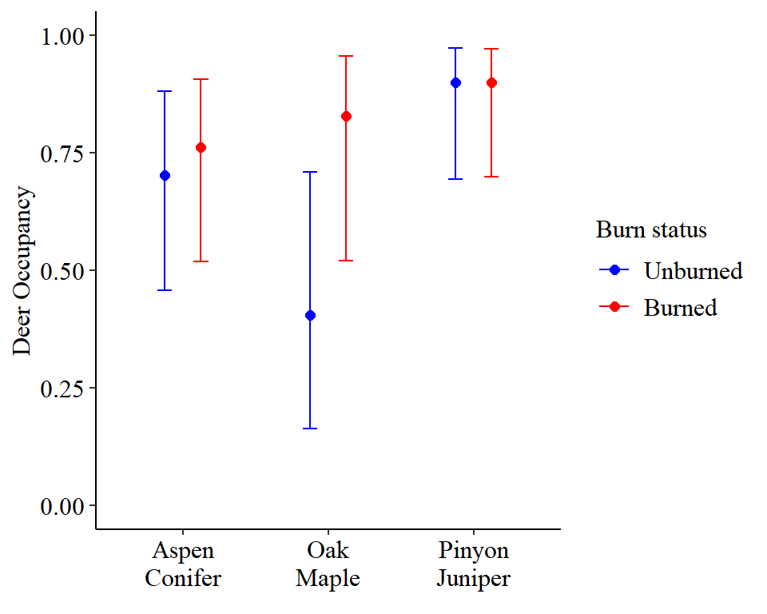

```r
# Create the plot using the defined jitter position
ggplot(data = q1.predict, aes(x = factor(Forest, level = c("A", "M", "J")), y = estimate,
                              colour = factor(Fire, level =c("0", "1")))) +
  geom_point(size = 2, position = position_dodge(0.5)) +
  geom_errorbar(aes(ymin = lower, ymax = upper), width = 0.2, position = position_dodge(0.5)) +
  ylab("Deer Occupancy")+
  theme_classic()+
  theme(text = element_text(family = "serif", size = 12))+
  scale_x_discrete(label = c("Aspen\nConifer","Oak\nMaple" ,
                             "Pinyon\nJuniper"
                             ))+
  scale_color_manual(values = c("0" = "blue", "1" = "red"),labels = c("Unburned", "Burned"))+
  theme(
    text = element_text(family = "serif", size = 12, color = "black"),
    axis.title = element_text(size = 12, color = "black"),
    axis.text = element_text(size = 12, color = "black"),
    legend.text = element_text(size = 12, color = "black"),
    legend.title = element_text(size = 12, color = "black"),
    plot.title = element_text(size = 12, color = "black"),
    plot.subtitle = element_text(size = 12, color = "black"),
    plot.caption = element_text(size = 12, color = "black")
  )+
  ylim(0,1)+
  xlab(element_blank())+
  labs(color = "Burn status")
```

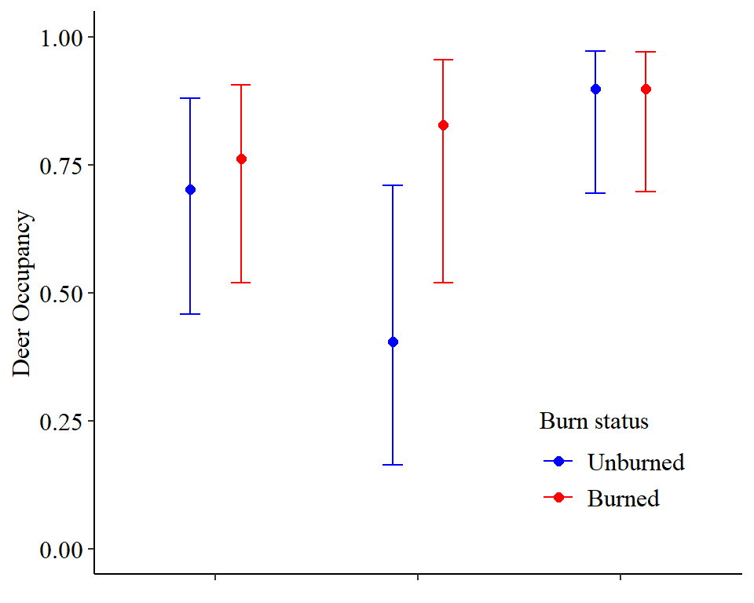

```r
#rerun without legend

d5 <- ggplot(data = q1.predict, aes(x = factor(Forest, level = c("A", "M", "J")), y = estimate,
                              colour = factor(Fire, level =c("0", "1")))) +
  geom_point(size = 2, position = position_dodge(0.5)) +
  geom_errorbar(aes(ymin = lower, ymax = upper), width = 0.2, position = position_dodge(0.5)) +
  ylab("Deer Occupancy")+
  theme_classic()+
  theme(text = element_text(family = "serif", size = 12))+
  #scale_x_discrete(label = c("Aspen\nConifer","Oak\nMaple" ,
  #                           "Pinyon\nJuniper"   ))+
  theme(axis.text.x = element_blank())+
  scale_color_manual(values = c("0" = "blue", "1" = "red"),labels = c("Unburned", "Burned"))+
  theme(
    text = element_text(family = "serif", size = 12, color = "black"),
    axis.title = element_text(size = 12, color = "black"),
    axis.text = element_text(size = 12, color = "black"),
    legend.text = element_text(size = 12, color = "black"),
    legend.title = element_text(size = 12, color = "black"),
    plot.title = element_text(size = 12, color = "black"),
    plot.subtitle = element_text(size = 12, color = "black"),
    plot.caption = element_text(size = 12, color = "black")
  )+
  ylim(0,1)+
  xlab(element_blank())+
  labs(color = "Burn status")+
  theme(legend.position= c(0.8,0.2))

d5
```

New block added Dec 2024 Separate plots by over time

```r
q1.2 = auto_occ(
  ~Forest * Year
  ~ Forest * Fire* Year,
  y = deer_y,
  det_covs = Year_frame,
  occ_covs = Year_frame
)

Year_frame
```

```
## $Year
##       [,1] [,2] [,3] [,4]
##  [1,]    1    2    3    4
##  [2,]    1    2    3    4
##  [3,]    1    2    3    4
##  [4,]    1    2    3    4
##  [5,]    1    2    3    4
##  [6,]    1    2    3    4
##  [7,]    1    2    3    4
##  [8,]    1    2    3    4
##  [9,]    1    2    3    4
## [10,]    1    2    3    4
## [11,]    1    2    3    4
## [12,]    1    2    3    4
## [13,]    1    2    3    4
```

[output cut: 62 more lines]

```r
summary(q1.2)
```

```
##
## Call:
## auto_occ(formula = ~Forest * Year ~ Forest * Fire * Year, y = deer_y,
##     det_covs = Year_frame, occ_covs = Year_frame)
##
##
## optim convergence code: 0
## optim iterations: 68
##
## Occupancy estimates:
##
##                   parameter     Est    SE  lower upper     p
## 1         psi - (Intercept)  0.7036 1.096 -1.444 2.851 0.521
## 2             psi - ForestJ -1.4199 1.920 -5.183 2.343 0.460
## 3             psi - ForestM -0.2790 1.696 -3.604 3.046 0.869
## 4               psi - Fire1  1.9603 1.783 -1.534 5.454 0.271
## 5                psi - Year -0.1512 0.441 -1.015 0.712 0.731
## 6       psi - ForestJ:Fire1 -0.9411 2.733 -6.298 4.416 0.731
## 7       psi - ForestM:Fire1 -0.3092 2.753 -5.706 5.087 0.911
## 8        psi - ForestJ:Year  1.3936 1.069 -0.701 3.488 0.192
## 9        psi - ForestM:Year -0.3271 0.665 -1.630 0.975 0.623
## 10         psi - Fire1:Year -0.6618 0.634 -1.905 0.582 0.297
## 11 psi - ForestJ:Fire1:Year  0.0154 1.344 -2.619 2.650 0.991
## 12 psi - ForestM:Fire1:Year  0.6776 1.006 -1.294 2.649 0.501
## 13              psi - theta  0.8006 0.562 -0.301 1.902 0.154
##
## Note: psi - theta is the autologistic term
##
## Detection estimates:
##
##             parameter     Est     SE   lower  upper        p
## 14  rho - (Intercept) -1.5678 0.2014 -1.9624 -1.173 6.93e-15
## 15      rho - ForestJ  0.1061 0.2698 -0.4226  0.635 6.94e-01
## 16      rho - ForestM  0.1658 0.3332 -0.4873  0.819 6.19e-01
## 17         rho - Year  0.2189 0.0755  0.0709  0.367 3.74e-03
## 18 rho - ForestJ:Year  0.2641 0.0976  0.0727  0.455 6.84e-03
## 19 rho - ForestM:Year -0.0449 0.1276 -0.2950  0.205 7.25e-01
##
## AIC: 2920.335
```

```r
# Create detection histories for each

deer_a = deer_y[substr(dimnames(deer_y)[[1]], 5, 5) == "A", , ]
deer_j = deer_y[substr(dimnames(deer_y)[[1]], 5, 5) == "J", , ]
deer_m = deer_y[substr(dimnames(deer_y)[[1]], 5, 5) == "M", , ]

# Get covariates for each forest type
rows_with_A <- Year_frame$Forest == "A"

# Filter each element of the list
aspenonly = lapply(Year_frame, function(df) {
  if (is.data.frame(df)) {
    # If df is a dataframe, subset with two dimensions
    df[rows_with_A, , drop = FALSE]
  } else {
    # If df is a vector, subset with a single dimension
    df[rows_with_A]
  }
})

#Year and season got outputted to lists of 48 instead of 12 x 4s so we need to out them into the right format
aspenonly$Year <- matrix(aspenonly$Year, nrow = 12, ncol = 4, byrow = FALSE)
aspenonly$Season <- matrix(aspenonly$Season, nrow = 12, ncol = 4, byrow = FALSE)

rows_with_M <- Year_frame$Forest == "M"

# Filter each element of the list
mapleonly = lapply(Year_frame, function(df) {
  if (is.data.frame(df)) {
    # If df is a dataframe, subset with two dimensions
    df[rows_with_M, , drop = FALSE]
  } else {
    # If df is a vector, subset with a single dimension
    df[rows_with_M]
  }
})

mapleonly$Year <- matrix(mapleonly$Year, nrow = 8, ncol = 4)
mapleonly$Season <- matrix(mapleonly$Season, nrow = 8, ncol = 4)

rows_with_J <- Year_frame$Forest == "J"

# Filter each element of the list
juniperonly = lapply(Year_frame, function(df) {
  if (is.data.frame(df)) {
    # If df is a dataframe, subset with two dimensions
    df[rows_with_J, , drop = FALSE]
  } else {
    # If df is a vector, subset with a single dimension
    df[rows_with_J]
  }
})

juniperonly$Year <- matrix(juniperonly$Year, nrow = 12, ncol = 4)
juniperonly$Season <- matrix(juniperonly$Season, nrow = 12, ncol = 4)
```

Create the individual models

```r
aonlynull <- aonlymod <- auto_occ(
  ~ Fire * Year
  ~ 1,
  y = deer_a,
  det_covs = aspenonly,
  occ_covs = aspenonly
)
summary(aonlynull)
```

```
##
## Call:
## auto_occ(formula = ~Fire * Year ~ 1, y = deer_a, det_covs = aspenonly,
##     occ_covs = aspenonly)
##
##
## optim convergence code: 0
## optim iterations: 34
##
## Occupancy estimates:
##
##           parameter    Est    SE   lower upper      p
## 1 psi - (Intercept)  1.070 0.517  0.0562  2.08 0.0386
## 2       psi - theta -0.313 0.672 -1.6302  1.00 0.6413
##
## Note: psi - theta is the autologistic term
##
## Detection estimates:
##
##           parameter     Est    SE   lower  upper        p
## 3 rho - (Intercept) -1.2108 0.295 -1.7894 -0.632 0.000041
## 4       rho - Fire1 -0.6688 0.403 -1.4593  0.122 0.097294
## 5        rho - Year  0.0336 0.111 -0.1843  0.252 0.762218
## 6  rho - Fire1:Year  0.3520 0.152  0.0541  0.650 0.020565
##
## AIC: 963.9595
```

```r
aonlymod <- auto_occ(
  ~ Fire * Year
  ~ Fire  * Year,
  y = deer_a,
  det_covs = aspenonly,
  occ_covs = aspenonly
)

summary(aonlymod)
```

```
##
## Call:
## auto_occ(formula = ~Fire * Year ~ Fire * Year, y = deer_a, det_covs = aspenonly,
##     occ_covs = aspenonly)
##
##
## optim convergence code: 0
## optim iterations: 39
##
## Occupancy estimates:
##
##           parameter    Est    SE  lower upper     p
## 1 psi - (Intercept)  0.584 1.113 -1.598 2.766 0.600
## 2       psi - Fire1  2.430 1.969 -1.430 6.289 0.217
## 3        psi - Year  0.104 0.482 -0.841 1.049 0.829
## 4  psi - Fire1:Year -0.799 0.688 -2.147 0.549 0.245
## 5       psi - theta -0.179 0.797 -1.742 1.383 0.822
##
## Note: psi - theta is the autologistic term
##
## Detection estimates:
##
##           parameter     Est    SE   lower  upper        p
## 6 rho - (Intercept) -1.2103 0.295 -1.7882 -0.632 4.05e-05
## 7       rho - Fire1 -0.6806 0.406 -1.4765  0.115 9.37e-02
## 8        rho - Year  0.0336 0.111 -0.1843  0.251 7.63e-01
## 9  rho - Fire1:Year  0.3556 0.153  0.0563  0.655 1.99e-02
##
## AIC: 967.5681
```

```r
aspen.pred <- predict(aonlymod, type = "psi")

d.a.g <- ggplot(data = aspen.pred, aes(y= estimate, x= Year, colour = Fire))+
  geom_smooth()+
  geom_ribbon(aes(ymin = lower, ymax = upper), alpha = 0.1, linetype = "dashed", fill = "white")+
  theme_classic()+
  ylab("Occupancy")+
  labs(color = "Forest Type")+
  scale_color_manual(values = c("0" = "blue", "1"= "red"),label = c("Unburned",
                            "Burned"))+
  theme(plot.title    = element_text(size=12, family = "serif", colour = "black"),
        plot.subtitle = element_text(size=12, family = "serif"),
        axis.title.x  = element_text(size=12, family = "serif", colour = "black"),
        axis.title.y  = element_text(size=12, family = "serif", colour = "black"),
        axis.text.x   = element_text(size=12, family = "serif", colour = "black"),
        axis.text.y   = element_text(size=12, family = "serif", colour = "black"),
        legend.text   = element_text(size=12, family = "serif", colour = "black"),
        legend.title  = element_text(size=12, family = "serif", colour = "black"),
        panel.border  = element_blank())+
  scale_y_continuous(limits = c(0, 1))

monlymod <- auto_occ(
  ~ Fire * Year
  ~ Fire  * Year,
  y = deer_m,
  det_covs = mapleonly,
  occ_covs = mapleonly
)

summary(monlymod)
```

```
##
## Call:
## auto_occ(formula = ~Fire * Year ~ Fire * Year, y = deer_m, det_covs = mapleonly,
##     occ_covs = mapleonly)
##
##
## optim convergence code: 0
## optim iterations: 38
##
## Occupancy estimates:
##
##           parameter    Est    SE  lower upper     p
## 1 psi - (Intercept)  1.092 1.620 -2.082 4.267 0.500
## 2       psi - Fire1  1.043 2.251 -3.369 5.455 0.643
## 3        psi - Year -0.905 0.735 -2.345 0.535 0.218
## 4  psi - Fire1:Year  0.122 0.866 -1.575 1.819 0.888
## 5       psi - theta  2.240 1.263 -0.235 4.716 0.076
##
## Note: psi - theta is the autologistic term
##
## Detection estimates:
##
##           parameter     Est    SE  lower  upper        p
## 6 rho - (Intercept) -2.6970 0.780 -4.225 -1.169 0.000541
## 7       rho - Fire1  1.7463 0.837  0.105  3.387 0.037031
## 8        rho - Year  0.0308 0.319 -0.594  0.656 0.923008
## 9  rho - Fire1:Year  0.1416 0.340 -0.525  0.808 0.677333
##
## AIC: 511.7108
```

```r
monlynull <- auto_occ(
  ~ Fire * Year
  ~ 1,
  y = deer_m,
  det_covs = mapleonly,
  occ_covs = mapleonly
)

summary(monlynull)
```

```
##
## Call:
## auto_occ(formula = ~Fire * Year ~ 1, y = deer_m, det_covs = mapleonly,
##     occ_covs = mapleonly)
##
##
## optim convergence code: 0
## optim iterations: 27
##
## Occupancy estimates:
##
##           parameter   Est    SE  lower upper     p
## 1 psi - (Intercept) 0.298 0.734 -1.141  1.74 0.685
## 2       psi - theta 1.358 1.083 -0.765  3.48 0.210
##
## Note: psi - theta is the autologistic term
##
## Detection estimates:
##
##           parameter    Est    SE  lower  upper       p
## 3 rho - (Intercept) -2.382 0.779 -3.909 -0.856 0.00222
## 4       rho - Fire1  1.432 0.837 -0.208  3.072 0.08703
## 5        rho - Year -0.236 0.339 -0.901  0.429 0.48721
## 6  rho - Fire1:Year  0.408 0.360 -0.297  1.113 0.25637
##
## AIC: 510.2012
```

```r
maple.pred <- predict(monlymod, type = "psi")

d.m.g <- ggplot(data = maple.pred, aes(y= estimate, x= Year, colour = Fire))+
  geom_smooth()+
  geom_ribbon(aes(ymin = lower, ymax = upper), alpha = 0.1, linetype = "dashed", fill = "white")+
  theme_classic()+
  ylab("Occupancy")+
  labs(color = "Forest Type")+
  scale_color_manual(values = c("0" = "blue", "1"= "red"),label = c("Unburned",
                            "Burned"))+
  theme(plot.title    = element_text(size=12, family = "serif", colour = "black"),
        plot.subtitle = element_text(size=12, family = "serif"),
        axis.title.x  = element_text(size=12, family = "serif", colour = "black"),
        axis.title.y  = element_text(size=12, family = "serif", colour = "black"),
        axis.text.x   = element_text(size=12, family = "serif", colour = "black"),
        axis.text.y   = element_text(size=12, family = "serif", colour = "black"),
        legend.text   = element_text(size=12, family = "serif", colour = "black"),
        legend.title  = element_text(size=12, family = "serif", colour = "black"),
        panel.border  = element_blank())+
  scale_y_continuous(limits = c(0, 1))

jonlymod <- auto_occ(
  ~ Fire * Year
  ~ Fire  * Year,
  y = deer_j,
  det_covs = juniperonly,
  occ_covs = juniperonly
)

summary(jonlymod)
```

```
##
## Call:
## auto_occ(formula = ~Fire * Year ~ Fire * Year, y = deer_j, det_covs = juniperonly,
##     occ_covs = juniperonly)
##
##
## optim convergence code: 0
## optim iterations: 38
##
## Occupancy estimates:
##
##           parameter    Est   SE lower upper     p
## 1 psi - (Intercept) -0.510 1.63 -3.71  2.69 0.755
## 2       psi - Fire1  0.975 2.05 -3.05  5.00 0.635
## 3        psi - Year  1.025 1.09 -1.12  3.17 0.348
## 4  psi - Fire1:Year -0.622 1.17 -2.91  1.67 0.595
## 5       psi - theta  1.409 1.54 -1.61  4.43 0.360
##
## Note: psi - theta is the autologistic term
##
## Detection estimates:
##
##           parameter    Est     SE   lower  upper        p
## 6 rho - (Intercept) -1.210 0.2506 -1.7016 -0.719 1.37e-06
## 7       rho - Fire1 -0.519 0.3603 -1.2249  0.188 1.50e-01
## 8        rho - Year  0.376 0.0855  0.2079  0.543 1.13e-05
## 9  rho - Fire1:Year  0.225 0.1245 -0.0195  0.469 7.13e-02
##
## AIC: 1394.75
```

```r
jonlynull <- auto_occ(
  ~ Fire * Year
  ~ 1,
  y = deer_j,
  det_covs = juniperonly,
  occ_covs = juniperonly
)

summary(jonlynull)
```

```
##
## Call:
## auto_occ(formula = ~Fire * Year ~ 1, y = deer_j, det_covs = juniperonly,
##     occ_covs = juniperonly)
##
##
## optim convergence code: 0
## optim iterations: 33
##
## Occupancy estimates:
##
##           parameter   Est    SE   lower upper      p
## 1 psi - (Intercept) 0.958 0.527 -0.0752  1.99 0.0692
## 2       psi - theta 2.409 1.145  0.1642  4.65 0.0354
##
## Note: psi - theta is the autologistic term
##
## Detection estimates:
##
##           parameter    Est     SE   lower  upper        p
## 3 rho - (Intercept) -1.211 0.2507 -1.7018 -0.719 1.37e-06
## 4       rho - Fire1 -0.519 0.3605 -1.2257  0.187 1.50e-01
## 5        rho - Year  0.376 0.0856  0.2079  0.543 1.14e-05
## 6  rho - Fire1:Year  0.225 0.1245 -0.0195  0.469 7.13e-02
##
## AIC: 1389.983
```

```r
juniper.pred <- predict(jonlymod, type = "psi")

d.j.g <- ggplot(data = juniper.pred, aes(y= estimate, x= Year, colour = Fire))+
  geom_smooth()+
  geom_ribbon(aes(ymin = lower, ymax = upper), alpha = 0.1, linetype = "dashed", fill = "white")+
  theme_classic()+
  ylab("Occupancy")+
  labs(color = "Forest Type")+
  scale_color_manual(values = c("0" = "blue", "1"= "red"),label = c("Unburned",
                            "Burned"))+
  theme(plot.title    = element_text(size=12, family = "serif", colour = "black"),
        plot.subtitle = element_text(size=12, family = "serif"),
        axis.title.x  = element_text(size=12, family = "serif", colour = "black"),
        axis.title.y  = element_text(size=12, family = "serif", colour = "black"),
        axis.text.x   = element_text(size=12, family = "serif", colour = "black"),
        axis.text.y   = element_text(size=12, family = "serif", colour = "black"),
        legend.text   = element_text(size=12, family = "serif", colour = "black"),
        legend.title  = element_text(size=12, family = "serif", colour = "black"),
        panel.border  = element_blank())+
  scale_y_continuous(limits = c(0, 1))

Year_frame
```

```
## $Year
##       [,1] [,2] [,3] [,4]
##  [1,]    1    2    3    4
##  [2,]    1    2    3    4
##  [3,]    1    2    3    4
##  [4,]    1    2    3    4
##  [5,]    1    2    3    4
##  [6,]    1    2    3    4
##  [7,]    1    2    3    4
##  [8,]    1    2    3    4
##  [9,]    1    2    3    4
## [10,]    1    2    3    4
## [11,]    1    2    3    4
## [12,]    1    2    3    4
## [13,]    1    2    3    4
```

[output cut: 62 more lines]

Question 2 How does occupancy change in response to fire severity across forest types?

```r
#Create covariates for each site


sev.df <- read.csv("C:/Users/ryanp/Documents/Academia/Dissertation/Chapter4_Camera traps/Dynamic_Occ/Chapter-4/FireSeverity.csv")
sev.df <-sev.df[-c(27,28),]

sev.df <- sev.df %>% replace(is.na(.), 0)

deer_covariates$FireSev <- sev.df$Fire_severity
head(deer_covariates)
```

```
##        Site Forest Fire FireSev
## 1 CLE_A_000      A    0       2
## 2 CLE_A_100      A    1       4
## 3 CLE_J_000      J    0       0
## 4 CLE_J_100      J    1       2
## 5 DA2_J_000      J    0       0
## 6 DA2_J_100      J    1       2
```

Best detection for Fire Severity

```r
# make named list (don't worry about the warning)
Year_frame <- list(
   Year = matrix(
     dh$Year,
     ncol = dim(deer_y)[2],
     nrow = dim(deer_y)[1]
   ),
   Forest = deer_covariates$Forest,
   FireSev = deer_covariates$FireSev,
   Season = matrix(seasons,
                   ncol = dim(deer_y)[2],
     nrow = dim(deer_y)[1])
 )

# modeling with no covariates
pnull <- auto_occ(
  formula = ~1  # detection
            ~1, # occupancy
  y = deer_y
)



p1 <- auto_occ(
      ~ Forest
      ~1,
      y= deer_y,
      det_covs = Year_frame
)

p2 <- auto_occ(
      ~ FireSev
      ~1,
      y= deer_y,
      det_covs = Year_frame
)

p3 <- auto_occ(
      ~ Year
      ~1,
      y= deer_y,
      det_covs = Year_frame
)


p4 <- auto_occ(
      ~ Forest + FireSev
      ~1,
      y= deer_y,
      det_covs = Year_frame
)

p5 <- auto_occ(
      ~ Forest * FireSev
      ~1,
      y= deer_y,
      det_covs = Year_frame
)

p6 <- auto_occ(
      ~ Forest + Year
      ~1,
      y= deer_y,
      det_covs = Year_frame
)

p7 <- auto_occ(
      ~ Forest * Year
      ~1,
      y= deer_y,
      det_covs = Year_frame
)

p8 <- auto_occ(
      ~ FireSev + Year
      ~1,
      y= deer_y,
      det_covs = Year_frame
)

p9 <- auto_occ(
      ~ FireSev * Year
      ~1,
      y= deer_y,
      det_covs = Year_frame
)

# Comparing models
detection.aic <- compare_models(
  list(null = pnull,
       Forest = p1,
       FireSev = p2,
       Year = p3,
       `Forest+FireSev` = p4,
       `Forest*FireSev` = p5,
       `Forest+Year` = p6,
       `Forest*Year` =p7,
       `FireSev+Year` = p8,
       `FireSev*Year` = p9),
  digits = 2
)

dfsd <- detection.aic
dfsd
```

```
##             model npar     AIC  delta AICwt cumltvWt
## 1     Forest*Year    8 2918.63   0.00  0.97     0.97
## 2     Forest+Year    6 2925.39   6.77  0.03     1.00
## 3  Forest*FireSev    8 2971.51  52.89  0.00     1.00
## 4  Forest+FireSev    6 2979.91  61.28  0.00     1.00
## 5    FireSev*Year    6 2986.21  67.58  0.00     1.00
## 6    FireSev+Year    5 2986.26  67.64  0.00     1.00
## 7          Forest    5 2988.45  69.83  0.00     1.00
## 8            Year    4 2992.08  73.46  0.00     1.00
## 9         FireSev    4 3064.05 145.42  0.00     1.00
## 10           null    3 3078.19 159.56  0.00     1.00
```

```r
summary(p7)
```

```
##
## Call:
## auto_occ(formula = ~Forest * Year ~ 1, y = deer_y, det_covs = Year_frame)
##
##
## optim convergence code: 0
## optim iterations: 44
##
## Occupancy estimates:
##
##           parameter   Est    SE lower upper      p
## 1 psi - (Intercept) 0.590 0.285 0.031  1.15 0.0386
## 2       psi - theta 0.971 0.427 0.134  1.81 0.0230
##
## Note: psi - theta is the autologistic term
##
## Detection estimates:
##
##            parameter     Est     SE   lower  upper        p
## 3  rho - (Intercept) -1.5644 0.2006 -1.9576 -1.171 6.32e-15
## 4      rho - ForestJ  0.1026 0.2692 -0.4250  0.630 7.03e-01
## 5      rho - ForestM  0.1678 0.3322 -0.4832  0.819 6.13e-01
## 6         rho - Year  0.2175 0.0753  0.0698  0.365 3.88e-03
## 7 rho - ForestJ:Year  0.2656 0.0975  0.0745  0.457 6.45e-03
## 8 rho - ForestM:Year -0.0463 0.1273 -0.2959  0.203 7.16e-01
##
## AIC: 2918.625
```

```r
#write.csv(dfsd, "Deer_FireSev_Detection.csv")
### Best model is model 7 Forest * Year acounting for 97% of the weight
```

Occupancy response to fire severity across fire types

```r
q2 <- auto_occ(
  ~Forest * Year
  ~ Forest * FireSev,
  y = deer_y,
  det_covs = Year_frame,
  occ_covs = Year_frame
)

summary(q2)
```

```
##
## Call:
## auto_occ(formula = ~Forest * Year ~ Forest * FireSev, y = deer_y,
##     det_covs = Year_frame, occ_covs = Year_frame)
##
##
## optim convergence code: 0
## optim iterations: 57
##
## Occupancy estimates:
##
##               parameter     Est    SE   lower upper      p
## 1     psi - (Intercept)  0.4104 1.149 -1.8417 2.663 0.7210
## 2         psi - ForestJ  0.6097 1.329 -1.9944 3.214 0.6463
## 3         psi - ForestM -1.5383 1.493 -4.4637 1.387 0.3027
## 4         psi - FireSev  0.0125 0.346 -0.6659 0.691 0.9712
## 5 psi - ForestJ:FireSev  0.3813 0.587 -0.7697 1.532 0.5161
## 6 psi - ForestM:FireSev  0.4578 0.503 -0.5288 1.444 0.3631
## 7           psi - theta  0.8435 0.447 -0.0326 1.720 0.0591
##
## Note: psi - theta is the autologistic term
##
## Detection estimates:
##
##             parameter    Est     SE   lower  upper        p
## 8   rho - (Intercept) -1.564 0.2005 -1.9569 -1.171 6.07e-15
## 9       rho - ForestJ  0.101 0.2693 -0.4264  0.629 7.06e-01
## 10      rho - ForestM  0.166 0.3319 -0.4850  0.816 6.18e-01
## 11         rho - Year  0.218 0.0753  0.0700  0.365 3.85e-03
## 12 rho - ForestJ:Year  0.266 0.0975  0.0746  0.457 6.42e-03
## 13 rho - ForestM:Year -0.045 0.1273 -0.2944  0.204 7.24e-01
##
## AIC: 2918.954
```

```r
q2_b <- summary(q2)
```

```
##
## Call:
## auto_occ(formula = ~Forest * Year ~ Forest * FireSev, y = deer_y,
##     det_covs = Year_frame, occ_covs = Year_frame)
##
##
## optim convergence code: 0
## optim iterations: 57
##
## Occupancy estimates:
##
##               parameter     Est    SE   lower upper      p
## 1     psi - (Intercept)  0.4104 1.149 -1.8417 2.663 0.7210
## 2         psi - ForestJ  0.6097 1.329 -1.9944 3.214 0.6463
## 3         psi - ForestM -1.5383 1.493 -4.4637 1.387 0.3027
## 4         psi - FireSev  0.0125 0.346 -0.6659 0.691 0.9712
## 5 psi - ForestJ:FireSev  0.3813 0.587 -0.7697 1.532 0.5161
## 6 psi - ForestM:FireSev  0.4578 0.503 -0.5288 1.444 0.3631
## 7           psi - theta  0.8435 0.447 -0.0326 1.720 0.0591
##
## Note: psi - theta is the autologistic term
##
## Detection estimates:
##
##             parameter    Est     SE   lower  upper        p
## 8   rho - (Intercept) -1.564 0.2005 -1.9569 -1.171 6.07e-15
## 9       rho - ForestJ  0.101 0.2693 -0.4264  0.629 7.06e-01
## 10      rho - ForestM  0.166 0.3319 -0.4850  0.816 6.18e-01
## 11         rho - Year  0.218 0.0753  0.0700  0.365 3.85e-03
## 12 rho - ForestJ:Year  0.266 0.0975  0.0746  0.457 6.42e-03
## 13 rho - ForestM:Year -0.045 0.1273 -0.2944  0.204 7.24e-01
##
## AIC: 2918.954
```

```r
dq2_b <- q2_b@rho
oq2_b <- q2_b@psi

write.csv(dq2_b, "Det_Deer_Q2_Betas.csv")
write.csv(oq2_b, "Occ_Deer_Q2_Betas.csv")

# nd1 <- data.frame(Forest= "A", Fire=as.factor(1), years=c(2:5), effort=14)
# nd2 <- data.frame(Forest= "A", Fire=as.factor(0), years=c(2:5), effort=14)
# nd3 <- data.frame(Forest= "J", Fire=as.factor(1), years=c(2:5), effort=14)
# nd4 <- data.frame(Forest= "J", Fire=as.factor(0), years=c(2:5), effort=14)
# nd5 <- data.frame(Forest= "M", Fire=as.factor(1), years=c(2:5), effort=14)
# nd6 <- data.frame(Forest= "M", Fire=as.factor(0), years=c(2:5), effort=14)
#
# nd <- rbind(nd1,nd2,nd3,nd4,nd5,nd6)
# nd

nd1 <- data.frame(Forest= "A", FireSev = c(0:4))

nd3 <- data.frame(Forest= "J", FireSev= c(0:4))

nd5 <- data.frame(Forest= "M", FireSev = c(0:4))


nd <- rbind(nd1,nd3,nd5)
nd
```

```
##    Forest FireSev
## 1       A       0
## 2       A       1
## 3       A       2
## 4       A       3
## 5       A       4
## 6       J       0
## 7       J       1
## 8       J       2
## 9       J       3
## 10      J       4
## 11      M       0
## 12      M       1
## 13      M       2
## 14      M       3
## 15      M       4
```

```r
q2.predict <- predict(q2, type = "psi", newdata = nd)
q2.predict <- cbind(nd, q2.predict)
q2.predict
```

```
##    Forest FireSev  estimate      lower     upper
## 1       A       0 0.7260964 0.16043241 0.9720991
## 2       A       1 0.7297472 0.28997145 0.9480180
## 3       A       2 0.7351552 0.44938802 0.9084431
## 4       A       3 0.7391522 0.56171940 0.8651280
## 5       A       4 0.7430375 0.52238743 0.8876471
## 6       J       0 0.8472918 0.54718924 0.9626827
## 7       J       1 0.8966074 0.75845240 0.9588315
## 8       J       2 0.9305168 0.76818008 0.9811036
## 9       J       3 0.9534695 0.68532696 0.9937918
## 10      J       4 0.9690533 0.56226924 0.9981511
## 11      M       0 0.3021848 0.04889935 0.8044911
## 12      M       1 0.4284086 0.14387085 0.7727688
## 13      M       2 0.5696339 0.33672632 0.7848687
## 14      M       3 0.6984310 0.42937163 0.8708759
## 15      M       4 0.7991629 0.42318101 0.9527290
```

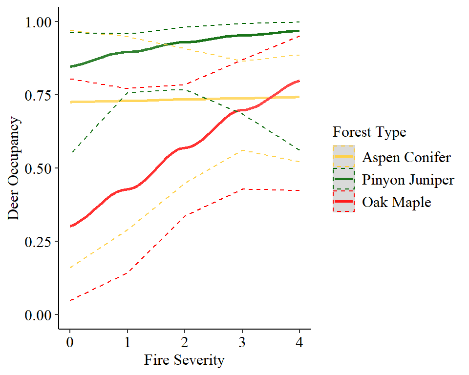

```r
ggplot(data = q2.predict, aes(y= estimate, x= FireSev, colour = Forest))+
  geom_smooth()+
  geom_ribbon(aes(ymin = lower, ymax = upper), alpha = 0.1, linetype = "dashed", fill = "white")+
  theme_classic()+
  ylab("Deer Occupancy")+
  xlab("Fire Severity")+
  labs(color = "Forest Type")+
  scale_color_manual(values = c("A" = "#FFCC33", "M"= "red", "J"= "darkgreen"),label = c("Aspen Conifer",
                            "Pinyon Juniper",
                            "Oak Maple"))+
  theme(plot.title    = element_text(size=12, family = "serif", colour = "black"),
        plot.subtitle = element_text(size=12, family = "serif"),
        axis.title.x  = element_text(size=12, family = "serif", colour = "black"),
        axis.title.y  = element_text(size=12, family = "serif", colour = "black"),
        axis.text.x   = element_text(size=12, family = "serif", colour = "black"),
        axis.text.y   = element_text(size=12, family = "serif", colour = "black"),
        legend.text   = element_text(size=12, family = "serif", colour = "black"),
        legend.title  = element_text(size=12, family = "serif", colour = "black"),
        panel.border  = element_blank())+
  scale_y_continuous(limits = c(0, 1))
```

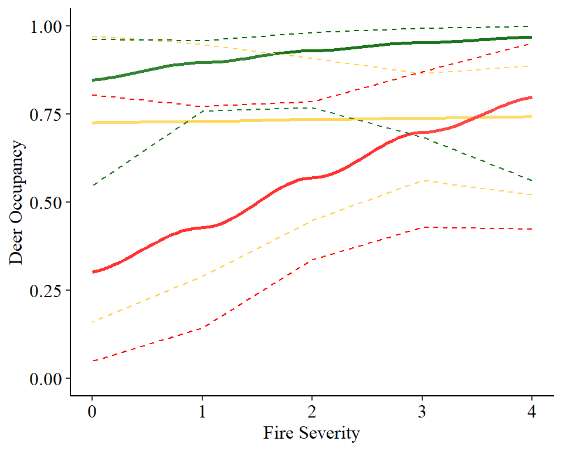

```r
# Rpeat no legend

ggplot(data = q2.predict, aes(y= estimate, x= FireSev, colour = Forest))+
  geom_smooth()+
  geom_ribbon(aes(ymin = lower, ymax = upper), alpha = 0.1, linetype = "dashed", fill = "white")+
  theme_classic()+
  ylab("Deer Occupancy")+
  xlab("Fire Severity")+
  labs(color = "Forest Type")+
  scale_color_manual(values = c("A" = "#FFCC33", "M"= "red", "J"= "darkgreen"),label = c("Aspen Conifer",
                            "Pinyon Juniper",
                            "Oak Maple"))+
  theme(plot.title    = element_text(size=12, family = "serif", colour = "black"),
        plot.subtitle = element_text(size=12, family = "serif"),
        axis.title.x  = element_text(size=12, family = "serif", colour = "black"),
        axis.title.y  = element_text(size=12, family = "serif", colour = "black"),
        axis.text.x   = element_text(size=12, family = "serif", colour = "black"),
        axis.text.y   = element_text(size=12, family = "serif", colour = "black"),
        legend.text   = element_text(size=12, family = "serif", colour = "black"),
        legend.title  = element_text(size=12, family = "serif", colour = "black"),
        panel.border  = element_blank())+
  scale_y_continuous(limits = c(0, 1))+
  theme(legend.position = "none")
```

Question 3 How does occupancy vary across time in burned areas across forest types? This is where model selection comes in

Fitting models

```r
# make named list (don't worry about the warning)
Year_frame <- list(
   Year = matrix(
     dh$Year,
     ncol = dim(deer_y)[2],
     nrow = dim(deer_y)[1]
   ),
   Forest = deer_covariates$Forest,
   Fire = deer_covariates$Fire,
   Season = matrix(seasons,
                   ncol = dim(deer_y)[2],
     nrow = dim(deer_y)[1])
 )


### Lets find the best occupancy model

# Find best occupancy model
psinull <- auto_occ(
      ~ Forest* Year
      ~1,
      y= deer_y,
      det_covs = Year_frame,
      occ_covs = Year_frame
)

psi1 <- auto_occ(
      ~ Forest* Year
      ~ Forest,
      y= deer_y,
      det_covs = Year_frame,
      occ_covs = Year_frame
)

psi2 <- auto_occ(
      ~ Forest* Year
      ~ Fire,
      y= deer_y,
      det_covs = Year_frame,
      occ_covs = Year_frame
)

psi3 <- auto_occ(
      ~ Forest* Year
      ~ Year,
      y= deer_y,
      det_covs = Year_frame,
      occ_covs = Year_frame
)




psi4 <- auto_occ(
      ~ Forest* Year
      ~ Forest + Fire,
      y= deer_y,
      det_covs = Year_frame,
      occ_covs = Year_frame
)



psi5 <- auto_occ(
      ~ Forest* Year
      ~ Forest * Fire,
      y= deer_y,
      det_covs = Year_frame,
      occ_covs = Year_frame
)

psi6 <- auto_occ(
      ~ Forest* Year
      ~ Forest + Year,
      y= deer_y,
      det_covs = Year_frame,
      occ_covs = Year_frame
)

psi7 <- auto_occ(
      ~ Forest* Year
      ~ Forest * Year,
      y= deer_y,
      det_covs = Year_frame,
      occ_covs = Year_frame
)

psi8 <- auto_occ(
      ~ Forest* Year
      ~ Fire + Year,
      y= deer_y,
      det_covs = Year_frame,
      occ_covs = Year_frame
)

psi9 <- auto_occ(
      ~ Forest* Year
      ~ Fire * Year,
      y= deer_y,
      det_covs = Year_frame,
      occ_covs = Year_frame
)



# Comparing models
psi.aic <- compare_models(
  list(null = psinull,
       Forest = psi1,
       Fire = psi2,
       Year = psi3,
       `Forest+Fire` = psi4,
       `Forest*Fire` = psi5,
       `Forest+Year` = psi6,
       `Forest*Year` =psi7,
       `Fire+Year` = psi8,
       `Fire*Year` = psi9),
  digits = 2
)
psi.aic
```

```
##          model npar     AIC delta AICwt cumltvWt
## 1  Forest*Year   13 2914.12  0.00  0.33     0.33
## 2       Forest   10 2915.39  1.27  0.17     0.51
## 3  Forest+Fire   11 2915.45  1.33  0.17     0.67
## 4  Forest+Year   11 2916.17  2.05  0.12     0.79
## 5  Forest*Fire   13 2917.01  2.90  0.08     0.87
## 6         null    8 2918.63  4.51  0.03     0.91
## 7         Fire    9 2918.78  4.66  0.03     0.94
## 8         Year    9 2919.07  4.95  0.03     0.96
## 9    Fire+Year   10 2919.40  5.28  0.02     0.99
## 10   Fire*Year   11 2920.81  6.69  0.01     1.00
```

```r
dfb <- summary(psi7)
```

```
##
## Call:
## auto_occ(formula = ~Forest * Year ~ Forest * Year, y = deer_y,
##     det_covs = Year_frame, occ_covs = Year_frame)
##
##
## optim convergence code: 0
## optim iterations: 57
##
## Occupancy estimates:
##
##            parameter     Est    SE   lower upper      p
## 1  psi - (Intercept)  1.5786 0.830 -0.0482 3.205 0.0572
## 2      psi - ForestJ -1.6453 1.311 -4.2144 0.924 0.2094
## 3      psi - ForestM -0.5196 1.249 -2.9676 1.928 0.6774
## 4         psi - Year -0.5022 0.323 -1.1351 0.131 0.1199
## 5 psi - ForestJ:Year  1.2835 0.629  0.0501 2.517 0.0414
## 6 psi - ForestM:Year  0.0371 0.463 -0.8704 0.945 0.9361
## 7        psi - theta  1.0116 0.537 -0.0410 2.064 0.0596
##
## Note: psi - theta is the autologistic term
##
## Detection estimates:
##
##             parameter     Est     SE   lower  upper        p
## 8   rho - (Intercept) -1.5688 0.2014 -1.9635 -1.174 6.65e-15
## 9       rho - ForestJ  0.1071 0.2698 -0.4216  0.636 6.91e-01
## 10      rho - ForestM  0.1689 0.3328 -0.4834  0.821 6.12e-01
## 11         rho - Year  0.2195 0.0755  0.0715  0.367 3.64e-03
## 12 rho - ForestJ:Year  0.2635 0.0976  0.0722  0.455 6.95e-03
## 13 rho - ForestM:Year -0.0464 0.1275 -0.2963  0.203 7.16e-01
##
## AIC: 2914.116
```

```r
dfb
```

```
##
## Call:
## auto_occ(formula = ~Forest * Year ~ Forest * Year, y = deer_y,
##     det_covs = Year_frame, occ_covs = Year_frame)
##
##
## optim convergence code: 0
## optim iterations: 57
##
## Occupancy estimates:
##
##            parameter     Est    SE   lower upper      p
## 1  psi - (Intercept)  1.5786 0.830 -0.0482 3.205 0.0572
## 2      psi - ForestJ -1.6453 1.311 -4.2144 0.924 0.2094
## 3      psi - ForestM -0.5196 1.249 -2.9676 1.928 0.6774
## 4         psi - Year -0.5022 0.323 -1.1351 0.131 0.1199
## 5 psi - ForestJ:Year  1.2835 0.629  0.0501 2.517 0.0414
## 6 psi - ForestM:Year  0.0371 0.463 -0.8704 0.945 0.9361
## 7        psi - theta  1.0116 0.537 -0.0410 2.064 0.0596
##
## Note: psi - theta is the autologistic term
##
## Detection estimates:
##
##             parameter     Est     SE   lower  upper        p
## 8   rho - (Intercept) -1.5688 0.2014 -1.9635 -1.174 6.65e-15
## 9       rho - ForestJ  0.1071 0.2698 -0.4216  0.636 6.91e-01
## 10      rho - ForestM  0.1689 0.3328 -0.4834  0.821 6.12e-01
## 11         rho - Year  0.2195 0.0755  0.0715  0.367 3.64e-03
## 12 rho - ForestJ:Year  0.2635 0.0976  0.0722  0.455 6.95e-03
## 13 rho - ForestM:Year -0.0464 0.1275 -0.2963  0.203 7.16e-01
##
## AIC: 2914.116
```

```r
ddfb <- dfb@rho
odfb <- dfb@psi

typeof(dfb)
```

```
## [1] "S4"
```

```r
write.csv(ddfb, "Det_Deer_Fire_Betas.csv")
write.csv(odfb, "Occ_Deer_Fire_Betas.csv")

psi.aic
```

```
##          model npar     AIC delta AICwt cumltvWt
## 1  Forest*Year   13 2914.12  0.00  0.33     0.33
## 2       Forest   10 2915.39  1.27  0.17     0.51
## 3  Forest+Fire   11 2915.45  1.33  0.17     0.67
## 4  Forest+Year   11 2916.17  2.05  0.12     0.79
## 5  Forest*Fire   13 2917.01  2.90  0.08     0.87
## 6         null    8 2918.63  4.51  0.03     0.91
## 7         Fire    9 2918.78  4.66  0.03     0.94
## 8         Year    9 2919.07  4.95  0.03     0.96
## 9    Fire+Year   10 2919.40  5.28  0.02     0.99
## 10   Fire*Year   11 2920.81  6.69  0.01     1.00
```

```r
### Plot best model
summary(psi7)
```

```
##
## Call:
## auto_occ(formula = ~Forest * Year ~ Forest * Year, y = deer_y,
##     det_covs = Year_frame, occ_covs = Year_frame)
##
##
## optim convergence code: 0
## optim iterations: 57
##
## Occupancy estimates:
##
##            parameter     Est    SE   lower upper      p
## 1  psi - (Intercept)  1.5786 0.830 -0.0482 3.205 0.0572
## 2      psi - ForestJ -1.6453 1.311 -4.2144 0.924 0.2094
## 3      psi - ForestM -0.5196 1.249 -2.9676 1.928 0.6774
## 4         psi - Year -0.5022 0.323 -1.1351 0.131 0.1199
## 5 psi - ForestJ:Year  1.2835 0.629  0.0501 2.517 0.0414
## 6 psi - ForestM:Year  0.0371 0.463 -0.8704 0.945 0.9361
## 7        psi - theta  1.0116 0.537 -0.0410 2.064 0.0596
##
## Note: psi - theta is the autologistic term
##
## Detection estimates:
##
##             parameter     Est     SE   lower  upper        p
## 8   rho - (Intercept) -1.5688 0.2014 -1.9635 -1.174 6.65e-15
## 9       rho - ForestJ  0.1071 0.2698 -0.4216  0.636 6.91e-01
## 10      rho - ForestM  0.1689 0.3328 -0.4834  0.821 6.12e-01
## 11         rho - Year  0.2195 0.0755  0.0715  0.367 3.64e-03
## 12 rho - ForestJ:Year  0.2635 0.0976  0.0722  0.455 6.95e-03
## 13 rho - ForestM:Year -0.0464 0.1275 -0.2963  0.203 7.16e-01
##
## AIC: 2914.116
```

```r
bdf <- predict(psi7, type = "psi")
bdf
```

```
##      estimate     lower     upper Year Forest Fire Season
## 1   0.8707637 0.6218656 0.9676576    1      A    0   Fall
## 2   0.8707637 0.6218656 0.9676576    1      A    1   Fall
## 3   0.8128226 0.4943213 0.9569596    1      J    0   Fall
## 4   0.8128226 0.4943213 0.9569596    1      J    1 Winter
## 5   0.8128226 0.4943213 0.9569596    1      J    0 Winter
## 6   0.8128226 0.4943213 0.9569596    1      J    1 Winter
## 7   0.8707637 0.6218656 0.9676576    1      A    0 Winter
## 8   0.8707637 0.6218656 0.9676576    1      A    1 Winter
## 9   0.8128226 0.4943213 0.9569596    1      J    0 Winter
## 10  0.8128226 0.4943213 0.9569596    1      J    1 Winter
## 11  0.7934522 0.4549268 0.9516325    1      M    0 Winter
## 12  0.7934522 0.4549268 0.9516325    1      M    1 Winter
## 13  0.8128226 0.4943213 0.9569596    1      J    0 Spring
## 14  0.8128226 0.4943213 0.9569596    1      J    1 Spring
```

[output cut: 114 more lines]

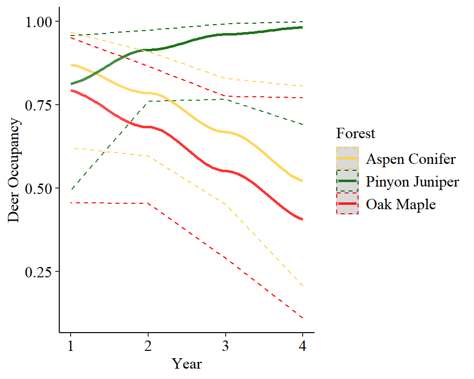

```r
ggplot(data = bdf, aes(x= Year, y= estimate, colour = Forest))+
  geom_smooth()+
  geom_ribbon(aes(ymin = lower, ymax = upper), alpha = 0.1, linetype = "dashed", fill = "white")+
  ylab("Deer Occupancy")+
  theme_classic()+
  scale_color_manual(values = c("A" = "#FFCC33", "M"= "red", "J"= "darkgreen"),label = c("Aspen Conifer",
                            "Pinyon Juniper",
                            "Oak Maple"))+
  theme(
    text = element_text(family = "serif", size = 12, color = "black"),
    axis.title = element_text(size = 12, color = "black"),
    axis.text = element_text(size = 12, color = "black"),
    legend.text = element_text(size = 12, color = "black"),
    legend.title = element_text(size = 12, color = "black"),
    plot.title = element_text(size = 12, color = "black"),
    plot.subtitle = element_text(size = 12, color = "black"),
    plot.caption = element_text(size = 12, color = "black")
  )
```

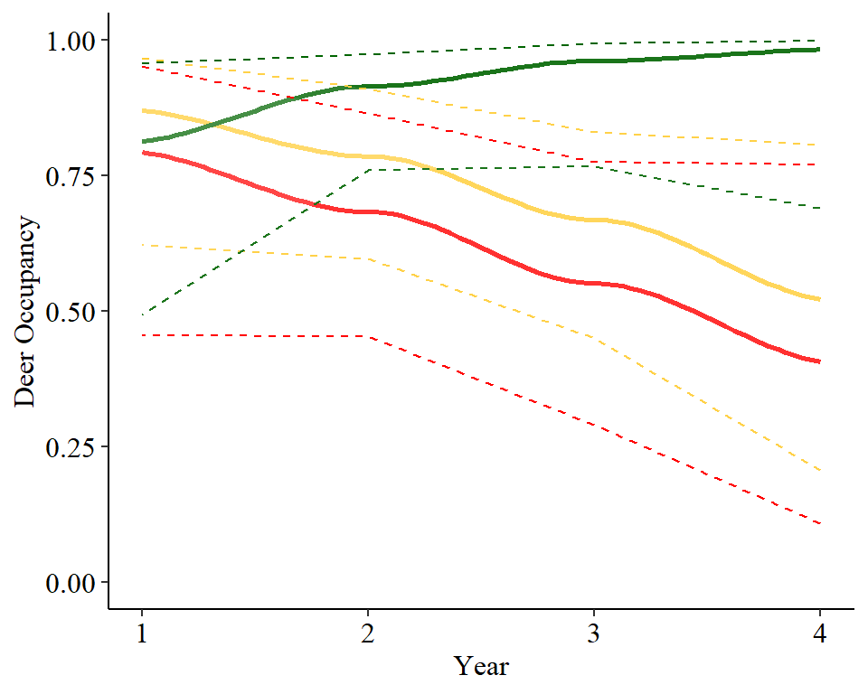

```r
# Rerun without legend

ggplot(data = bdf, aes(x= Year, y= estimate, colour = Forest))+
  geom_smooth()+
  geom_ribbon(aes(ymin = lower, ymax = upper), alpha = 0.1, linetype = "dashed", fill = "white")+
  ylim(0,1)+
  ylab("Deer Occupancy")+
  theme_classic()+
  scale_color_manual(values = c("A" = "#FFCC33", "M"= "red", "J"= "darkgreen"),label = c("Aspen Conifer",
                            "Pinyon Juniper",
                            "Oak Maple"))+
  theme(
    text = element_text(family = "serif", size = 12, color = "black"),
    axis.title = element_text(size = 12, color = "black"),
    axis.text = element_text(size = 12, color = "black"),
    legend.text = element_text(size = 12, color = "black"),
    legend.title = element_text(size = 12, color = "black"),
    plot.title = element_text(size = 12, color = "black"),
    plot.subtitle = element_text(size = 12, color = "black"),
    plot.caption = element_text(size = 12, color = "black")
  )+
  theme(legend.position="none")
```

[figure not shown]

```r
 dbo <- psi.aic
#write.csv(dbo, "Deer_Burned_Occupancy.csv")

variables <- list(
  Forest = c("Forest*Year", "Forest", "Forest+Fire", "Forest+Year", "Forest*Fire"),
  Year = c("Forest*Year", "Forest+Year", "Year", "Fire+Year", "Fire*Year"),
  Fire = c("Forest+Fire", "Fire", "Forest*Fire", "Fire+Year", "Fire*Year")
)
variables <- list(
  Forest = c("Forest", "Forest+Fire", "Forest+Year"),
  Year = c( "Forest+Year", "Year", "Fire+Year"),
  Fire = c("Forest+Fire", "Fire", "Fire+Year"),
  ForestFire = "Forest*Fire",
  ForestYear = "Forest * Year",
  FireYear = "Fire * Year"
)

#### Lots of top competing models

#Calculate relative variable importance

importance<- sapply(variables, function(models){
  sum(psi.aic$AICwt[psi.aic$model %in% models])
})

importance <- as.data.frame(importance)
importance$variable <- row.names(importance)

deer_importance <- importance

ggplot(importance, aes(y = importance, x = variable)) +
  geom_col(size = 2, fill = "#666666", width = 0.75) +
  geom_text(aes(label = importance), vjust = -0.2, size = 4) +
  labs(y = "Relative Importance (w+)", x = "Predictor Variable",
       title = "Deer Fire") +
  scale_x_discrete(label =c("Fire", "Forest", "Year"))+
  theme_classic() +
  ylim(0, 1)+
  theme(
     text = element_text(family = "serif", size = 12, color = "black"),
    axis.title = element_text(size = 12, color = "black"),
    axis.text = element_text(size = 12, color = "black"),
    legend.text = element_text(size = 12, color = "black"),
    legend.title = element_text(size = 12, color = "black"),
    plot.title = element_text(size = 12, color = "black"),
    plot.subtitle = element_text(size = 12, color = "black"),
    plot.caption = element_text(size = 12, color = "black")
  )+
    scale_y_continuous(expand = c(0, 0), limits = c(0,1))
```

```r
summary(psinull)
```

```
##
## Call:
## auto_occ(formula = ~Forest * Year ~ 1, y = deer_y, det_covs = Year_frame,
##     occ_covs = Year_frame)
##
##
## optim convergence code: 0
## optim iterations: 44
##
## Occupancy estimates:
##
##           parameter   Est    SE lower upper      p
## 1 psi - (Intercept) 0.590 0.285 0.031  1.15 0.0386
## 2       psi - theta 0.971 0.427 0.134  1.81 0.0230
##
## Note: psi - theta is the autologistic term
##
## Detection estimates:
##
##            parameter     Est     SE   lower  upper        p
## 3  rho - (Intercept) -1.5644 0.2006 -1.9576 -1.171 6.32e-15
## 4      rho - ForestJ  0.1026 0.2692 -0.4250  0.630 7.03e-01
## 5      rho - ForestM  0.1678 0.3322 -0.4832  0.819 6.13e-01
## 6         rho - Year  0.2175 0.0753  0.0698  0.365 3.88e-03
## 7 rho - ForestJ:Year  0.2656 0.0975  0.0745  0.457 6.45e-03
## 8 rho - ForestM:Year -0.0463 0.1273 -0.2959  0.203 7.16e-01
##
## AIC: 2918.625
```

```r
#backTransform(psi7, type = "psi")
#backTransform
```

Model Averaging

```r
# To model average, get the parameters in each model,
# and set up a binary matrix to denote if they were present or not in that model.

# create model list again
model_list <- list(a=psinull,b=psi1,c=psi2,d=psi3,e=psi4,f=psi5,g=psi6,h=psi7, i=psi8, j=psi9)

# and AIC results
aic_results <- compare_models(
  model_list
)

aic_results
```

```
##    model npar      AIC    delta      AICwt  cumltvWt
## 1      h   13 2914.116 0.000000 0.33020117 0.3302012
## 2      b   10 2915.386 1.270589 0.17493376 0.5051349
## 3      e   11 2915.450 1.334511 0.16943112 0.6745661
## 4      g   11 2916.169 2.053850 0.11824719 0.7928132
## 5      f   13 2917.013 2.897178 0.07756473 0.8703780
## 6      a    8 2918.625 4.509388 0.03463996 0.9050179
## 7      c    9 2918.780 4.664598 0.03205339 0.9370713
## 8      d    9 2919.067 4.951782 0.02776596 0.9648373
## 9      i   10 2919.398 5.282451 0.02353472 0.9883720
## 10     j   11 2920.808 6.692571 0.01162801 1.0000000
```

```r
# reorder the model_list based on relative fit
model_list <- model_list[aic_results$model]

model_list
```

```
## $h
##
## Call:
## auto_occ(formula = ~Forest * Year ~ Forest * Year, y = deer_y,
##     det_covs = Year_frame, occ_covs = Year_frame)
##
##             parameter         Est         SE       lower      upper
## 1   psi - (Intercept)  1.57855865 0.82997207 -0.04815670  3.2052740
## 2       psi - ForestJ -1.64525878 1.31080926 -4.21439772  0.9238802
## 3       psi - ForestM -0.51964263 1.24896375 -2.96756659  1.9282813
## 4          psi - Year -0.50217198 0.32292714 -1.13509755  0.1307536
## 5  psi - ForestJ:Year  1.28348148 0.62927836  0.05011857  2.5168444
## 6  psi - ForestM:Year  0.03711766 0.46302002 -0.87038490  0.9446202
## 7         psi - theta  1.01155600 0.53702784 -0.04099923  2.0641112
## 8   rho - (Intercept) -1.56883418 0.20136613 -1.96350453 -1.1741638
## 9       rho - ForestJ  0.10710172 0.26977279 -0.42164323  0.6358467
## 10      rho - ForestM  0.16888745 0.33281168 -0.48341147  0.8211864
## 11         rho - Year  0.21951072 0.07549438  0.07154444  0.3674770
## 12 rho - ForestJ:Year  0.26353395 0.09763875  0.07216552  0.4549024
## 13 rho - ForestM:Year -0.04643572 0.12747073 -0.29627376  0.2034023
##               p
## 1  5.717875e-02
## 2  2.094253e-01
## 3  6.773668e-01
## 4  1.199311e-01
## 5  4.138934e-02
## 6  9.361066e-01
## 7  5.961649e-02
## 8  6.650526e-15
## 9  6.913622e-01
## 10 6.118346e-01
## 11 3.641638e-03
## 12 6.953326e-03
## 13 7.156449e-01
##
## AIC: 2914.116
##
## $b
##
## Call:
```

[output cut: 235 more lines]

```
## 11 rho - ForestM:Year -0.04619355 0.12748376 -0.29605713  0.2036700
##               p
## 1  4.374021e-01
## 2  2.177251e-01
## 3  6.425396e-01
## 4  4.442482e-01
## 5  1.551280e-02
## 6  6.448887e-15
## 7  6.979055e-01
## 8  6.146637e-01
## 9  3.751133e-03
## 10 6.709946e-03
## 11 7.170916e-01
##
## AIC: 2920.808
```

```r
aic_results$model
```

```
##  [1] "h" "b" "e" "g" "f" "a" "c" "d" "i" "j"
```

```r
# specify confidence interval width
my_ci_width <- 0.95


# get only the model parameters
parms <- lapply(
  model_list,
  function(x){
    x@estimates$parameter
  }
)


# select only unique parameters
all_parms <- unique(
  unlist(
    parms
  )
)

# make an empty matrix
parm_matrix <- matrix(
  0,
  ncol = length(
    all_parms
  ),
  nrow = length(
    model_list
  )
)
colnames(parm_matrix) <- all_parms

# Add '1's to models which have parameter present
for(i in 1:nrow(parm_matrix)){
  parm_matrix[i, parms[[i]]] <- 1
}

# calculate overall weight for each parameter. The easiest
#  way to do this is to make a weight matrix.
weight_matrix <- matrix(
  aic_results$AICwt,
  nrow = length(model_list),
  ncol = length(all_parms)
)

parm_weight <- colSums(
  parm_matrix * weight_matrix
)

parm_weight
```

```
##   psi - (Intercept)       psi - ForestJ       psi - ForestM          psi - Year
##          1.00000000          0.87037797          0.87037797          0.51137704
##  psi - ForestJ:Year  psi - ForestM:Year         psi - theta   rho - (Intercept)
##          0.33020117          0.33020117          1.00000000          1.00000000
##       rho - ForestJ       rho - ForestM          rho - Year  rho - ForestJ:Year
##          1.00000000          1.00000000          1.00000000          1.00000000
##  rho - ForestM:Year         psi - Fire1 psi - ForestJ:Fire1 psi - ForestM:Fire1
##          1.00000000          0.31421196          0.07756473          0.07756473
##    psi - Fire1:Year
##          0.01162801
```

```r
#  We are going to take samples from the parameters (which
#  is the same thing we do to make predictions
#  via autoOcc::predict). To do that, we need
#  to get the variance covariance matrix
#  for each model.

cov_mat <- lapply(
  model_list,
  vcov
)

# and now the estimates (assuming you are not
# using any offsets in the model for this).

ests <- lapply(
  model_list,
  function(x) x@estimates$Est
)

# do 5000 samples for each parameter.
mvn_samps <- vector(
  "list",
  length = length(model_list)
)
nsim = 5000
set.seed(465)
for(i in 1:length(mvn_samps)){
  mvn_samps[[i]] <- mvtnorm::rmvnorm(
    nsim,
    mean = ests[[i]],
    sigma = cov_mat[[i]],
    method = "svd"
  )
  colnames(mvn_samps[[i]]) <- parms[[i]]
}

# do model averaging for each parameter
avg_parm <- data.frame(
  parameter = all_parms,
  est = NA,
  lower = NA,
  upper = NA
)

for(i in 1:nrow(avg_parm)){
  my_parm <- avg_parm$parameter[i]
  which_models <- which(
    parm_matrix[,i] == 1
  )

  weights <- weight_matrix[
    which_models,i
  ] * parm_matrix[
    which_models,i
  ]

  # get beta terms
  beta_mat <- matrix(
    NA,
    ncol = length(which_models),
    nrow = nsim
  )

  # multiply weight across columns while we do this
  for(j in 1:ncol(beta_mat)){
    beta_mat[,j] <- mvn_samps[[which_models[j]]][,my_parm] *
      weights[j]
  }

  # sum each row
  beta_mat <- rowSums(beta_mat)

  # divide by overall weight
  beta_mat <- beta_mat / parm_weight[i]

  # summarise
  avg_parm$est[i] <- median(beta_mat)
  avg_parm$lower[i] <- quantile(
    beta_mat,
    (1 - my_ci_width) / 2
  )
  avg_parm$upper[i] <- quantile(
    beta_mat,
    1 - ( (1 - my_ci_width) / 2 )
  )

}


# get average estimate
avg_parm %>%
  mutate(
    across(
      where(is.numeric), ~ round(., digits = 2))
    )
```

```
##              parameter   est lower upper
## 1    psi - (Intercept)  0.84  0.24  1.45
## 2        psi - ForestJ  0.03 -0.97  1.05
## 3        psi - ForestM -0.50 -1.49  0.49
## 4           psi - Year -0.41 -0.83  0.00
## 5   psi - ForestJ:Year  1.30  0.08  2.48
## 6   psi - ForestM:Year  0.03 -0.87  0.93
## 7          psi - theta  0.97  0.54  1.41
## 8    rho - (Intercept) -1.57 -1.74 -1.39
## 9        rho - ForestJ  0.10 -0.13  0.33
## 10       rho - ForestM  0.16 -0.12  0.46
## 11          rho - Year  0.22  0.15  0.28
## 12  rho - ForestJ:Year  0.26  0.18  0.35
## 13  rho - ForestM:Year -0.04 -0.16  0.06
## 14         psi - Fire1  0.54 -0.05  1.14
## 15 psi - ForestJ:Fire1 -0.25 -2.37  2.03
## 16 psi - ForestM:Fire1  1.41 -0.75  3.50
## 17    psi - Fire1:Year -0.29 -1.04  0.47
```

```r
data_filtered <- avg_parm %>%
  filter(!grepl("^rho", parameter))

data_filtered
```

```
##              parameter        est       lower        upper
## 1    psi - (Intercept)  0.8407053  0.24085610  1.448113645
## 2        psi - ForestJ  0.0288582 -0.96751083  1.049927374
## 3        psi - ForestM -0.5029699 -1.48634286  0.487790558
## 4           psi - Year -0.4102417 -0.83143112 -0.001835789
## 5   psi - ForestJ:Year  1.2950147  0.07625876  2.479877403
## 6   psi - ForestM:Year  0.0308394 -0.87257150  0.927744946
## 7          psi - theta  0.9723491  0.53911501  1.414116787
## 8          psi - Fire1  0.5352679 -0.04626380  1.142509155
## 9  psi - ForestJ:Fire1 -0.2547943 -2.37344908  2.033027297
## 10 psi - ForestM:Fire1  1.4074079 -0.75237626  3.497542648
## 11    psi - Fire1:Year -0.2924550 -1.04126371  0.470026465
```

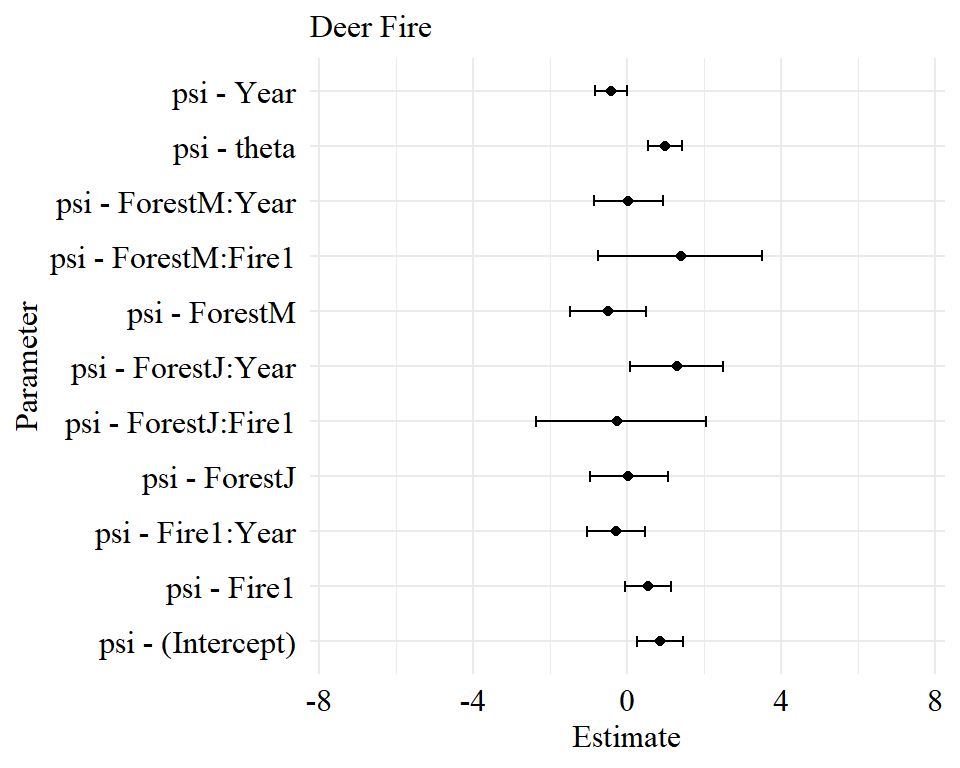

```r
ggplot(data= data_filtered, aes(x = est, y = parameter)) +
  geom_point() +
  geom_errorbarh(aes(xmin = lower, xmax = upper), height = 0.2) +
  labs(title = "Deer Fire",
       x = "Estimate",
       y = "Parameter") +
  theme_minimal()+
  theme(
    text = element_text(family = "serif", size = 12),
    axis.title = element_text(size = 12, color = "black"),
    axis.text = element_text(size = 12, color = "black"),
    legend.text = element_text(size = 12, color = "black"),
    legend.title = element_text(size = 12, color = "black"),
    plot.title = element_text(size = 12, color = "black"),
    plot.subtitle = element_text(size = 12, color = "black"),
    plot.caption = element_text(size = 12, color = "black")
  )+xlim(-7.5,7.5)
```

Predict occupancy

```r
#### Plot best model

nd1 <- data.frame(Forest= "A", Year = c(1:4))

nd3 <- data.frame(Forest= "J", Year = c(1:4))

nd5 <- data.frame(Forest= "M", Year = c(1:4))


nd <- rbind(nd1,nd3,nd5)
nd
```

```
##    Forest Year
## 1       A    1
## 2       A    2
## 3       A    3
## 4       A    4
## 5       J    1
## 6       J    2
## 7       J    3
## 8       J    4
## 9       M    1
## 10      M    2
## 11      M    3
## 12      M    4
```

```r
pred.top <- predict(psi7, type = "psi", newdata = nd)
pred.top <- cbind(nd, pred.top)

head(pred.top)
```

```
##   Forest Year  estimate     lower     upper
## 1      A    1 0.8703654 0.6159429 0.9677480
## 2      A    2 0.7879054 0.5986315 0.9076646
## 3      A    3 0.6693956 0.4482631 0.8320330
## 4      A    4 0.5182595 0.1976471 0.8032253
## 5      J    1 0.8181183 0.5050169 0.9558052
## 6      J    2 0.9152139 0.7617777 0.9738334
```

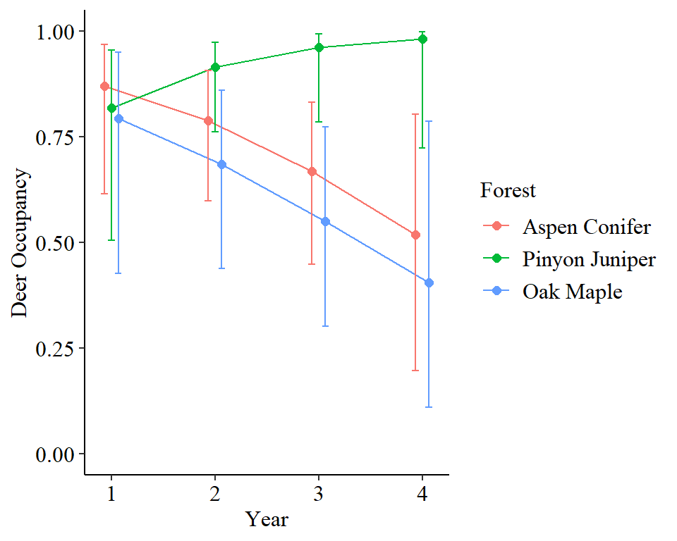

```r
ggplot(data = pred.top, aes(y= estimate, x=Year, colour = Forest))+
  geom_point(size = 2, position = position_dodge(0.2))+
  geom_line(position = position_dodge(0.2))+
  geom_errorbar(aes(ymin= lower, ymax = upper, width = 0.2), position = position_dodge(0.2))+
  theme_classic()+
  ylab("Deer Occupancy")+
  theme(text = element_text(family = "serif", size = 12))+
  scale_color_discrete(label = c("Aspen Conifer",
                             "Pinyon Juniper",
                             "Oak Maple"))+
  theme(
  text = element_text(family = "serif", size = 12, color = "black"),
    axis.title = element_text(size = 12, color = "black"),
    axis.text = element_text(size = 12, color = "black"),
    legend.text = element_text(size = 12, color = "black"),
    legend.title = element_text(size = 12, color = "black"),
    plot.title = element_text(size = 12, color = "black"),
    plot.subtitle = element_text(size = 12, color = "black"),
    plot.caption = element_text(size = 12, color = "black")
  )+
  ylim(0,1)
```

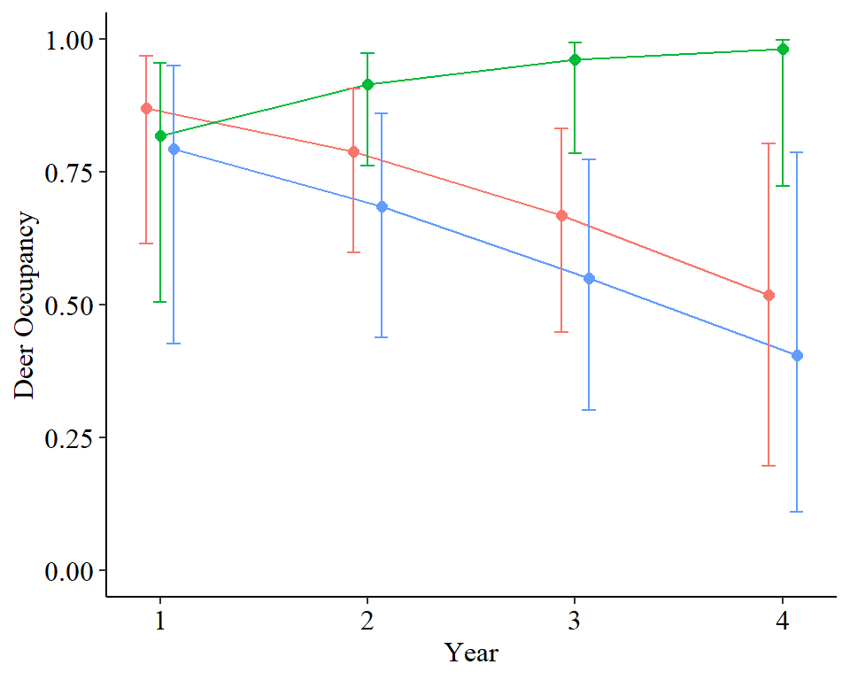

```r
#rerun without legend

ggplot(data = pred.top, aes(y= estimate, x=Year, colour = Forest))+
  geom_point(size = 2, position = position_dodge(0.2))+
  geom_line(position = position_dodge(0.2))+
  geom_errorbar(aes(ymin= lower, ymax = upper, width = 0.2), position = position_dodge(0.2))+
  theme_classic()+
  ylab("Deer Occupancy")+
  theme(text = element_text(family = "serif", size = 12))+
  scale_color_discrete(label = c("Aspen Conifer",
                             "Pinyon Juniper",
                             "Oak Maple"))+
  theme(
  text = element_text(family = "serif", size = 12, color = "black"),
    axis.title = element_text(size = 12, color = "black"),
    axis.text = element_text(size = 12, color = "black"),
    legend.text = element_text(size = 12, color = "black"),
    legend.title = element_text(size = 12, color = "black"),
    plot.title = element_text(size = 12, color = "black"),
    plot.subtitle = element_text(size = 12, color = "black"),
    plot.caption = element_text(size = 12, color = "black")
  )+
  ylim(0,1)+
  theme(legend.position="none")
```

Rerun model selection but with Fire Severity

Fitting models

```r
# make named list (don't worry about the warning)
Year_frame <- list(
   Year = matrix(
     dh$Year,
     ncol = dim(deer_y)[2],
     nrow = dim(deer_y)[1]
   ),
   Forest = deer_covariates$Forest,
   FireSev = deer_covariates$FireSev
 )


### Lets find the best occupancy model

# Find best occupancy model
psinull <- auto_occ(
      ~ Forest* Year
      ~1,
      y= deer_y,
      det_covs = Year_frame,
      occ_covs = Year_frame
)

psi1 <- auto_occ(
      ~ Forest* Year
      ~ Forest,
      y= deer_y,
      det_covs = Year_frame,
      occ_covs = Year_frame
)

psi2 <- auto_occ(
      ~ Forest* Year
      ~ FireSev,
      y= deer_y,
      det_covs = Year_frame,
      occ_covs = Year_frame
)

psi3 <- auto_occ(
      ~ Forest* Year
      ~ Year,
      y= deer_y,
      det_covs = Year_frame,
      occ_covs = Year_frame
)



psi4 <- auto_occ(
      ~ Forest* Year
      ~ Forest + FireSev,
      y= deer_y,
      det_covs = Year_frame,
      occ_covs = Year_frame
)



psi5 <- auto_occ(
      ~ Forest* Year
      ~ Forest * FireSev,
      y= deer_y,
      det_covs = Year_frame,
      occ_covs = Year_frame
)

psi6 <- auto_occ(
      ~ Forest* Year
      ~ Forest + Year,
      y= deer_y,
      det_covs = Year_frame,
      occ_covs = Year_frame
)

psi7 <- auto_occ(
      ~ Forest* Year
      ~ Forest * Year,
      y= deer_y,
      det_covs = Year_frame,
      occ_covs = Year_frame
)

psi8 <- auto_occ(
      ~ Forest* Year
      ~ FireSev + Year,
      y= deer_y,
      det_covs = Year_frame,
      occ_covs = Year_frame
)

psi9 <- auto_occ(
      ~ Forest* Year
      ~ FireSev * Year,
      y= deer_y,
      det_covs = Year_frame,
      occ_covs = Year_frame
)

# Comparing models
psi.aic <- compare_models(
  list(null = psinull,
       Forest = psi1,
       Fire = psi2,
       Year = psi3,
       `Forest+FireSev` = psi4,
       `Forest*FireSev` = psi5,
       `Forest+Year` = psi6,
       `Forest*Year` =psi7,
       `FireSev+Year` = psi8,
       `FireSev*Year` = psi9),
  digits = 2
)

psi.aic
```

```
##             model npar     AIC delta AICwt cumltvWt
## 1     Forest*Year   13 2914.12  0.00  0.36     0.36
## 2          Forest   10 2915.39  1.27  0.19     0.55
## 3  Forest+FireSev   11 2915.89  1.78  0.15     0.70
## 4     Forest+Year   11 2916.17  2.05  0.13     0.83
## 5    FireSev*Year   11 2918.38  4.26  0.04     0.87
## 6            null    8 2918.63  4.51  0.04     0.91
## 7  Forest*FireSev   13 2918.95  4.84  0.03     0.94
## 8            Year    9 2919.07  4.95  0.03     0.97
## 9            Fire    9 2920.48  6.37  0.01     0.99
## 10   FireSev+Year   10 2920.90  6.78  0.01     1.00
```

```r
dfsb <-summary(psi7)
```

```
##
## Call:
## auto_occ(formula = ~Forest * Year ~ Forest * Year, y = deer_y,
##     det_covs = Year_frame, occ_covs = Year_frame)
##
##
## optim convergence code: 0
## optim iterations: 57
##
## Occupancy estimates:
##
##            parameter     Est    SE   lower upper      p
## 1  psi - (Intercept)  1.5786 0.830 -0.0482 3.205 0.0572
## 2      psi - ForestJ -1.6453 1.311 -4.2144 0.924 0.2094
## 3      psi - ForestM -0.5196 1.249 -2.9676 1.928 0.6774
## 4         psi - Year -0.5022 0.323 -1.1351 0.131 0.1199
## 5 psi - ForestJ:Year  1.2835 0.629  0.0501 2.517 0.0414
## 6 psi - ForestM:Year  0.0371 0.463 -0.8704 0.945 0.9361
## 7        psi - theta  1.0116 0.537 -0.0410 2.064 0.0596
##
## Note: psi - theta is the autologistic term
##
## Detection estimates:
##
##             parameter     Est     SE   lower  upper        p
## 8   rho - (Intercept) -1.5688 0.2014 -1.9635 -1.174 6.65e-15
## 9       rho - ForestJ  0.1071 0.2698 -0.4216  0.636 6.91e-01
## 10      rho - ForestM  0.1689 0.3328 -0.4834  0.821 6.12e-01
## 11         rho - Year  0.2195 0.0755  0.0715  0.367 3.64e-03
## 12 rho - ForestJ:Year  0.2635 0.0976  0.0722  0.455 6.95e-03
## 13 rho - ForestM:Year -0.0464 0.1275 -0.2963  0.203 7.16e-01
##
## AIC: 2914.116
```

```r
ddfsb <- dfsb@rho
odfsb <- dfsb@psi

write.csv(ddfsb, "Det_Deer_FireSev_Betas.csv")
write.csv(odfsb, "Occ_Deer_FireSev_Betas.csv")

### Plot best model
bdfs <- predict(psi7, type = "psi")
bdfs
```

```
##      estimate     lower     upper Year Forest FireSev
## 1   0.8667445 0.6216523 0.9665738    1      A       2
## 2   0.8667445 0.6216523 0.9665738    1      A       4
## 3   0.8105497 0.5122742 0.9561213    1      J       0
## 4   0.8105497 0.5122742 0.9561213    1      J       2
## 5   0.8105497 0.5122742 0.9561213    1      J       0
## 6   0.8105497 0.5122742 0.9561213    1      J       2
## 7   0.8667445 0.6216523 0.9665738    1      A       3
## 8   0.8667445 0.6216523 0.9665738    1      A       4
## 9   0.8105497 0.5122742 0.9561213    1      J       1
## 10  0.8105497 0.5122742 0.9561213    1      J       2
## 11  0.7927180 0.4251774 0.9523773    1      M       2
## 12  0.7927180 0.4251774 0.9523773    1      M       4
## 13  0.8105497 0.5122742 0.9561213    1      J       0
## 14  0.8105497 0.5122742 0.9561213    1      J       2
```

[output cut: 114 more lines]

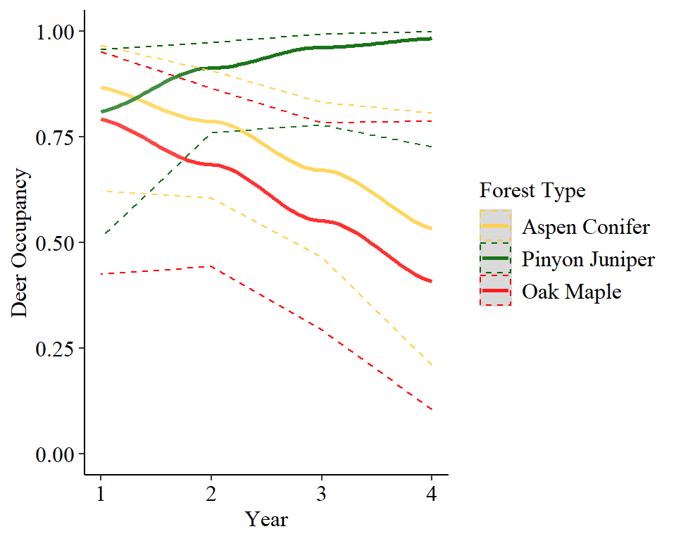

```r
#### Iteration 1####
ggplot(data = bdfs, aes(x= Year, y= estimate, colour = Forest))+
  geom_smooth()+
  geom_ribbon(aes(ymin = lower, ymax = upper), alpha = 0.1, linetype = "dashed", fill = "white")+
  theme_classic()+
  ylab("Deer Occupancy")+
  labs(color = "Forest Type")+
  scale_color_manual(values = c("A" = "#FFCC33", "M"= "red", "J"= "darkgreen"),label = c("Aspen Conifer",
                            "Pinyon Juniper",
                            "Oak Maple"))+
  theme(plot.title    = element_text(size=12, family = "serif", colour = "black"),
        plot.subtitle = element_text(size=12, family = "serif"),
        axis.title.x  = element_text(size=12, family = "serif", colour = "black"),
        axis.title.y  = element_text(size=12, family = "serif", colour = "black"),
        axis.text.x   = element_text(size=12, family = "serif", colour = "black"),
        axis.text.y   = element_text(size=12, family = "serif", colour = "black"),
        legend.text   = element_text(size=12, family = "serif", colour = "black"),
        legend.title  = element_text(size=12, family = "serif", colour = "black"),
        panel.border  = element_blank())+
  scale_y_continuous(limits = c(0, 1))
```

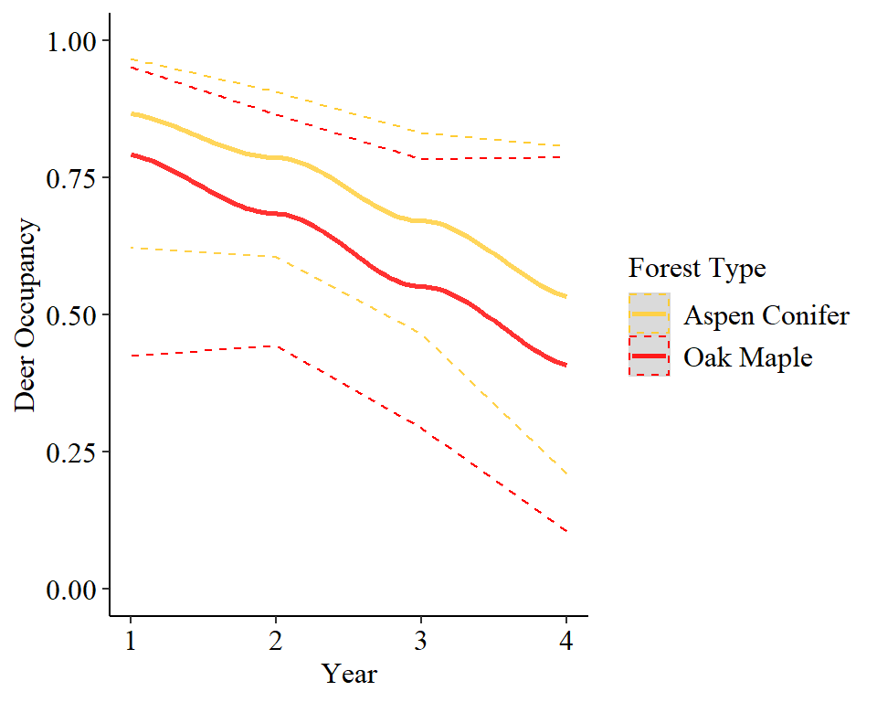

```r
#####ITeration 2 #####

ggplot(data = bdfs[bdfs$Forest!= "J",], aes(x= Year, y= estimate, colour = Forest))+
  geom_smooth()+
  geom_ribbon(aes(ymin = lower, ymax = upper), alpha = 0.1, linetype = "dashed", fill = "white")+
  theme_classic()+
  ylab("Deer Occupancy")+
  labs(color = "Forest Type")+
  scale_color_manual(values = c("A" = "#FFCC33", "M"= "red"),label = c("Aspen Conifer",
                            "Oak Maple",
                            "Pinyon Juniper"))+
  theme(plot.title    = element_text(size=12, family = "serif", colour = "black"),
        plot.subtitle = element_text(size=12, family = "serif"),
        axis.title.x  = element_text(size=12, family = "serif", colour = "black"),
        axis.title.y  = element_text(size=12, family = "serif", colour = "black"),
        axis.text.x   = element_text(size=12, family = "serif", colour = "black"),
        axis.text.y   = element_text(size=12, family = "serif", colour = "black"),
        legend.text   = element_text(size=12, family = "serif", colour = "black"),
        legend.title  = element_text(size=12, family = "serif", colour = "black"),
        panel.border  = element_blank())+
  scale_y_continuous(limits = c(0, 1))
```

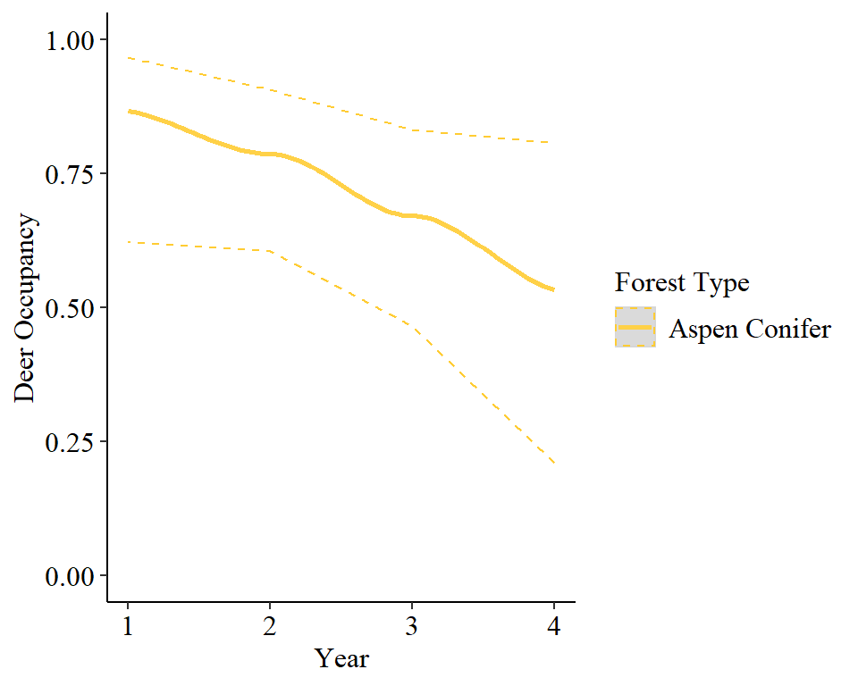

```r
#### Iteration 3 #####

ggplot(data = bdfs[bdfs$Forest== "A",], aes(x= Year, y= estimate, colour = Forest))+
  geom_smooth()+
  geom_ribbon(aes(ymin = lower, ymax = upper), alpha = 0.1, linetype = "dashed", fill = "white")+
  theme_classic()+
  ylab("Deer Occupancy")+
  labs(color = "Forest Type")+
  scale_color_manual(values = c("A"= "#FFCC33"),label = c("Aspen Conifer",
                             "Pinyon Juniper",
                             "Oak Maple"))+
  theme(plot.title    = element_text(size=12, family = "serif", colour = "black"),
        plot.subtitle = element_text(size=12, family = "serif"),
        axis.title.x  = element_text(size=12, family = "serif", colour = "black"),
        axis.title.y  = element_text(size=12, family = "serif", colour = "black"),
        axis.text.x   = element_text(size=12, family = "serif", colour = "black"),
        axis.text.y   = element_text(size=12, family = "serif", colour = "black"),
        legend.text   = element_text(size=12, family = "serif", colour = "black"),
        legend.title  = element_text(size=12, family = "serif", colour = "black"),
        panel.border  = element_blank())+
  scale_y_continuous(limits = c(0, 1))
```

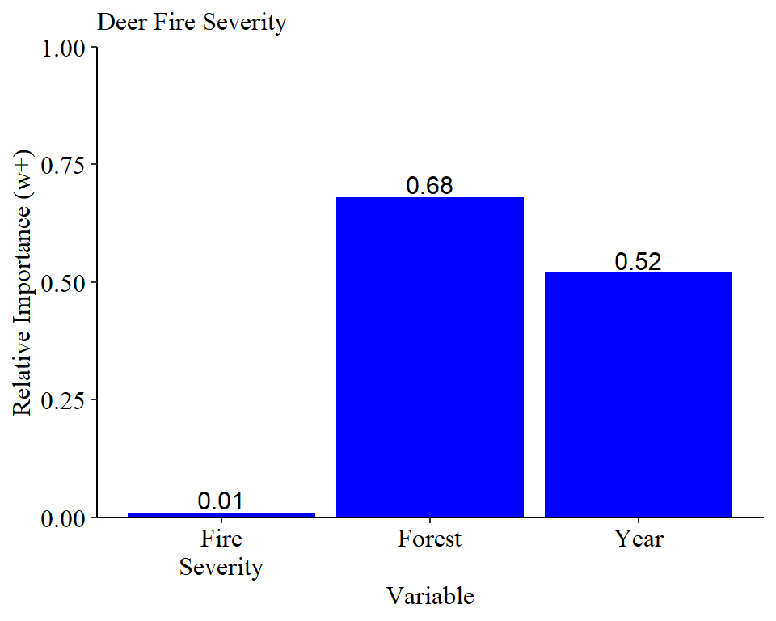

```r
###############

dfso <- psi.aic
#write.csv(dfso, "Deer_FireSev_Occupancy.csv")

variables <- list(
  Forest = c("Forest*Year", "Forest", "Forest+Fire", "Forest+Year", "Forest*Fire"),
  Year = c("Forest*Year", "Forest+Year", "Year", "Fire+Year", "Fire*Year"),
  `Fire Severity` = c("Forest+Fire", "Fire", "Forest*Fire", "Fire+Year", "Fire*Year")
)

#### Lots of top competing models

#Calculate relative variable importance

importance<- sapply(variables, function(models){
  sum(psi.aic$AICwt[psi.aic$model %in% models])
})

importance <- as.data.frame(importance)
importance$variable <- row.names(importance)


ggplot(importance, aes(y = importance, x = variable)) +
  geom_col(size = 3, fill = "blue") +
  geom_text(aes(label = importance), vjust = -0.2, size = 4) +
  labs(y = "Relative Importance (w+)", x = "Variable",
       title = "Deer Fire Severity") +
  scale_x_discrete(label =c("Fire\nSeverity", "Forest", "Year"))+
  theme_classic() +
  ylim(0, 1)+
  theme(
     text = element_text(family = "serif", size = 12, color = "black"),
    axis.title = element_text(size = 12, color = "black"),
    axis.text = element_text(size = 12, color = "black"),
    legend.text = element_text(size = 12, color = "black"),
    legend.title = element_text(size = 12, color = "black"),
    plot.title = element_text(size = 12, color = "black"),
    plot.subtitle = element_text(size = 12, color = "black"),
    plot.caption = element_text(size = 12, color = "black")
  )+
    scale_y_continuous(expand = c(0, 0), limits = c(0,1))
```